# AI-Assisted Reverse Translation and Ancestral DNA Reconstruction

# Project Overview

This project explores the reverse interpretation of the classical Central Dogma of Molecular Biology by computationally reconstructing probable DNA sequences from protein sequences using probabilistic evolutionary modeling, phylogenetics, codon optimization strategies, and machine learning-assisted inference.

The system aims to combine concepts from:

- Bioinformatics
- Computational Biology
- Evolutionary Genomics
- Probabilistic Modeling
- Machine Learning
- Sequence Analysis

to infer biologically plausible ancestral coding sequences from modern protein and genomic data.

# Background

The classical Central Dogma of Molecular Biology describes the flow of biological information:

DNA → RNA → Protein

However, reconstructing DNA from protein sequences is not straightforward because of codon degeneracy.

Multiple codons can encode the same amino acid.

Example:

| Amino Acid | Possible Codons |
| --- | --- |
| Leucine | UUA, UUG, CUU, CUC, CUA, CUG |
| Glycine | GGU, GGC, GGA, GGG |

Thus, a single protein sequence may correspond to many possible DNA sequences.

This project investigates computational strategies to probabilistically infer the most biologically plausible DNA sequence and extend this concept toward ancestral genome reconstruction.

# Problem Statement

Given:

- modern protein sequences
- homologous genes from related organisms
- evolutionary relationships between species

the objective is to infer:

1. probable coding DNA sequences
2. evolutionarily plausible ancestral sequences
3. optimized synthetic coding regions
4. codon usage patterns across species

using probabilistic and machine learning approaches.

# Objectives

## Primary Objectives

- Reverse translate protein sequences into probable DNA sequences
- Perform species-aware codon optimization
- Infer ancestral protein and DNA sequences
- Model evolutionary mutation patterns
- Reconstruct phylogenetic relationships

## Secondary Objectives

- Analyze codon usage bias
- Estimate evolutionary conservation
- Compare probabilistic reconstruction approaches
- Develop ML-assisted sequence reconstruction methods

# Core Research Questions

- Can protein sequences be used to infer biologically plausible DNA sequences?
- How accurately can ancestral sequences be reconstructed computationally?
- Can probabilistic evolutionary models improve reverse translation?
- Can machine learning models predict realistic ancestral coding sequences?

# Theoretical Foundations

## 1. Central Dogma

Biological information transfer:

```
DNA → RNA → Protein
```

This project attempts partial reverse inference:

```
Protein → Probable DNA
```

## 2. Codon Degeneracy

Multiple codons encode the same amino acid.

Example:

| Codon | Amino Acid |
| --- | --- |
| GAA | Glutamate |
| GAG | Glutamate |

This creates ambiguity in reverse translation.

## 3. Evolutionary Mutation Modeling

DNA sequences evolve through mutations over time.

Mutation examples:

```
A → G
C → T
```

These mutations can be modeled probabilistically using Markov processes.

## 4. Hidden Markov Models (HMM)

Observed sequences:

- modern proteins/DNA

Hidden states:

- ancestral sequences

The ancestral sequence is inferred probabilistically based on descendant sequences.

## 5. Phylogenetics

Closely related organisms share common ancestors.

Phylogenetic trees represent evolutionary relationships.

Example:

```
Ancestor
            /      \
       Primate    Rodent
```

## 6. Maximum Likelihood Estimation

The ancestral sequence is estimated by maximizing evolutionary probability.

Mathematically:

[ \hat{A} = \arg\max_A P(A \mid D) ]

Where:

- (A) = ancestral sequence
- (D) = observed descendant sequences

# Proposed Methodology

The workflow consists of multiple computational stages.

# Workflow Diagram

```
┌────────────────────────┐
                    │  Sequence Collection   │
                    │ (DNA / Protein FASTA)  │
                    └────────────┬───────────┘
                                 │
                                 ▼
                    ┌────────────────────────┐
                    │ Multiple Sequence      │
                    │ Alignment (MSA)        │
                    └────────────┬───────────┘
                                 │
                                 ▼
                    ┌────────────────────────┐
                    │ Phylogenetic Tree      │
                    │ Construction           │
                    └────────────┬───────────┘
                                 │
                                 ▼
                    ┌────────────────────────┐
                    │ Evolutionary Modeling  │
                    │ & Mutation Analysis    │
                    └────────────┬───────────┘
                                 │
                                 ▼
                    ┌────────────────────────┐
                    │ Ancestral Sequence     │
                    │ Reconstruction         │
                    └────────────┬───────────┘
                                 │
                                 ▼
                    ┌────────────────────────┐
                    │ Reverse Translation    │
                    │ Protein → DNA          │
                    └────────────┬───────────┘
                                 │
                                 ▼
                    ┌────────────────────────┐
                    │ Codon Optimization     │
                    │ Species Adaptation     │
                    └────────────┬───────────┘
                                 │
                                 ▼
                    ┌────────────────────────┐
                    │ ML-Based Refinement    │
                    │ and Prediction         │
                    └────────────────────────┘
```

# Detailed Methodological Breakdown

## Phase 1 — Data Collection

### Input Sources

Sequences will be collected from biological databases such as:

- NCBI
- UniProt
- Ensembl

### Data Types

- DNA sequences
- protein sequences
- homologous genes

## Phase 2 — Sequence Alignment

Multiple sequence alignment will identify conserved and mutated regions across species.

Purpose:

- detect evolutionary similarity
- identify mutation sites
- preserve homologous residue positions

Tools:

- MUSCLE
- Clustal Omega
- MAFFT

## Phase 3 — Phylogenetic Analysis

Phylogenetic trees will be constructed to model evolutionary relationships.

Methods:

- Neighbor Joining
- Maximum Likelihood Trees
- Bayesian Phylogeny

Purpose:

- identify common ancestors
- estimate divergence relationships

## Phase 4 — Evolutionary Modeling

Mutation probabilities will be modeled computationally.

This includes:

- nucleotide substitution modeling
- transition probabilities
- evolutionary distance estimation

Possible approaches:

- Markov chains
- Hidden Markov Models
- probabilistic substitution matrices

## Phase 5 — Ancestral Sequence Reconstruction

Probabilistic inference methods will estimate ancestral sequences from descendant sequences.

Approaches:

- Maximum likelihood estimation
- Bayesian inference
- HMM-based inference

Outputs:

- ancestral amino acid sequences
- ancestral nucleotide sequences

## Phase 6 — Reverse Translation

Protein sequences will be computationally converted into candidate DNA sequences.

Challenges:

- codon degeneracy
- ambiguous mappings

Solutions:

- codon probability distributions
- species-specific codon usage patterns

## Phase 7 — Codon Optimization

Generated DNA sequences will be optimized for:

- GC-content balance
- translation efficiency
- organism-specific codon preference

Applications:

- synthetic biology
- recombinant protein expression

## Phase 8 — Machine Learning Integration

Machine learning models may be used to predict biologically plausible coding sequences.

Potential architectures:

- sequence-to-sequence models
- recurrent neural networks
- transformers

Input:

- protein sequences
- evolutionary features
- codon frequencies

Output:

- optimized coding DNA sequences

# Expected Outcomes

The project aims to produce:

- reconstructed ancestral sequences
- probabilistic DNA candidates
- codon-optimized sequences
- evolutionary mutation analyses
- ML-assisted reconstruction models

# Potential Applications

- evolutionary biology
- synthetic biology
- genomic engineering
- protein engineering
- ancestral protein reconstruction
- vaccine development
- computational genomics

# Limitations

- exact original DNA reconstruction is biologically impossible in many cases
- ancestral reconstruction is probabilistic
- evolutionary assumptions may introduce uncertainty

# Future Scope

Possible future extensions include:

- deep generative biological sequence models
- ancestral genome simulation
- mutation prediction systems
- adaptive evolutionary forecasting
- protein structure-aware reconstruction

# Conclusion

This project investigates a computational reverse interpretation of biological information flow by integrating evolutionary modeling, probabilistic inference, phylogenetics, and machine learning to reconstruct biologically plausible ancestral coding sequences from modern protein and genomic data.

The work combines theoretical biological principles with advanced computational strategies to explore evolutionary reconstruction at both sequence and genomic levels.

```python
# ============================================================
# PACKAGE INSTALLATION
# ============================================================

!pip install biopython -q
!pip install ete3 -q
!pip install dendropy -q
!pip install transformers -q

# ============================================================
# GENERAL UTILITIES
# ============================================================

import os
import re
import json
import random
import warnings

# ============================================================
# NUMERICAL + DATA PROCESSING
# ============================================================

import numpy as np
import pandas as pd

# ============================================================
# VISUALIZATION
# ============================================================

import matplotlib.pyplot as plt
import seaborn as sns

# ============================================================
# BIOINFORMATICS
# ============================================================

from Bio import SeqIO
from Bio import Phylo

from Bio.Seq import Seq
from Bio.SeqRecord import SeqRecord

from Bio.Align import PairwiseAligner
from Bio import pairwise2

from Bio.Data import CodonTable

from Bio.Phylo.TreeConstruction import (
    DistanceCalculator,
    DistanceTreeConstructor
)

# ============================================================
# PHYLOGENETICS
# ============================================================

import dendropy

# ============================================================
# MACHINE LEARNING
# ============================================================

from sklearn.model_selection import train_test_split
from sklearn.preprocessing import LabelEncoder
from sklearn.metrics import accuracy_score

# ============================================================
# DEEP LEARNING
# ============================================================

import torch
import torch.nn as nn
import torch.optim as optim

# ============================================================
# CONFIGURATION
# ============================================================

warnings.filterwarnings("ignore")

SEED = 42

random.seed(SEED)
np.random.seed(SEED)
torch.manual_seed(SEED)

plt.rcParams["figure.figsize"] = (12, 6)

# ============================================================
# ENVIRONMENT CHECK
# ============================================================

print("=" * 75)
print(" AI-Assisted Reverse Translation & Ancestral Reconstruction ")
print("=" * 75)

print("\nEnvironment initialized successfully.\n")

print("Loaded Components:")
print("✓ Sequence Processing")
print("✓ Reverse Translation Utilities")
print("✓ Phylogenetic Tree Construction")
print("✓ Evolutionary Analysis Support")
print("✓ Machine Learning Framework")
print("✓ Deep Learning Framework")

print("\nSystem Ready for Pipeline Development.")
```

[output not shown]

```
===========================================================================
 AI-Assisted Reverse Translation & Ancestral Reconstruction
===========================================================================

Environment initialized successfully.

Loaded Components:
✓ Sequence Processing
✓ Reverse Translation Utilities
✓ Phylogenetic Tree Construction
✓ Evolutionary Analysis Support
✓ Machine Learning Framework
✓ Deep Learning Framework

System Ready for Pipeline Development.
```

# Step 1 — Load FASTA Sequences

### Goal

Load real protein FASTA sequences from multiple species.

### Why

These sequences will be used later for:

- sequence alignment
- mutation analysis
- phylogenetic reconstruction
- ancestral sequence inference

### Input

FASTA files for:

- human
- chimpanzee
- gorilla
- mouse
- rat.

```python
# ============================================================
# STEP 1 — LOAD FASTA FILES
# ============================================================
from Bio import SeqIO
# ------------------------------------------------------------
# FILE PATHS
# ------------------------------------------------------------
fasta_files = {

    "Human": "/kaggle/input/datasets/somshirsha/protein/human_cytochrome.fasta",
    "Chimpanzee": "/kaggle/input/datasets/somshirsha/protein/chimpanzee_cytochrome.fasta",
    "Gorilla": "/kaggle/input/datasets/somshirsha/gorilla/gorilla_cytochrome.fasta",
    "Mouse": "/kaggle/input/datasets/somshirsha/protein/mouse_cytochrome.fasta",
    "Rat": "/kaggle/input/datasets/somshirsha/protein/rat_cytochrome.fasta"
}
# ------------------------------------------------------------
# LOAD SEQUENCES
# ------------------------------------------------------------
protein_sequences = {}
for species, filepath in fasta_files.items():
    record = SeqIO.read(filepath, "fasta")
    sequence = str(record.seq)
    protein_sequences[species] = sequence
# ------------------------------------------------------------
# DISPLAY LOADED SEQUENCES
# ------------------------------------------------------------
print("=" * 70)
print("Loaded Protein Sequences")
print("=" * 70)
for species, sequence in protein_sequences.items():
    print(f"\nSpecies : {species}")
    print(f"Length  : {len(sequence)} amino acids")
    print(f"Sequence:\n{sequence}")
```

```
======================================================================
Loaded Protein Sequences
======================================================================

Species : Human
Length  : 105 amino acids
Sequence:
MGDVEKGKKIFIMKCSQCHTVEKGGKHKTGPNLHGLFGRKTGQAPGYSYTAANKNKGIIWGEDTLMEYLENPKKYIPGTKMIFVGIKKKEERADLIAYLKKATNE

Species : Chimpanzee
Length  : 105 amino acids
Sequence:
MGDVEKGKKIFIMKCSQCHTVEKGGKHKTGPNLHGLFGRKTGQAPGYSYTAANKNKGIIWGEDTLMEYLENPKKYIPGTKMIFVGIKKKEERADLIAYLKKATNE

Species : Gorilla
Length  : 105 amino acids
Sequence:
MGDVEKGKKIFIMKCSQCHTVEKGGKHKTGPNLHGLFGRKTGQAPGYSYTAANKNKGIIWGEDTLMEYLENPKKYIPGTKMIFVGIKKKEERADLIAYLKKATNE

Species : Mouse
Length  : 105 amino acids
Sequence:
MGDVEKGKKIFVQKCAQCHTVEKGGKHKTGPNLHGLFGRKTGQAAGFSYTDANKNKGITWGEDTLMEYLENPKKYIPGTKMIFAGIKKKGERADLIAYLKKATNE

Species : Rat
Length  : 105 amino acids
Sequence:
MGDVEKGKKIFVQKCAQCHTVEKGGKHKTGPNLHGLFGRKTGQAAGFSYTDANKNKGITWGEDTLMEYLENPKKYIPGTKMIFAGIKKKGERADLIAYLKKATNE
```

# Step 2 — Sequence Validation

### Goal

Validate the biological consistency of loaded protein sequences.

### Why

Sequence inconsistencies can affect:

- alignment quality
- mutation analysis
- phylogenetic inference

### What We Check

- sequence lengths
- invalid amino acid characters
- duplicate sequences
- unusual variations

```python
# ============================================================
# STEP 2 — SEQUENCE VALIDATION
# ============================================================

# Standard amino acids
valid_amino_acids = set("ACDEFGHIKLMNPQRSTVWY")

print("=" * 70)
print("Sequence Validation Report")
print("=" * 70)

# ------------------------------------------------------------
# VALIDATE EACH SEQUENCE
# ------------------------------------------------------------

for species, sequence in protein_sequences.items():

    print(f"\nSpecies : {species}")

    # --------------------------------------------------------
    # Sequence length
    # --------------------------------------------------------

    print(f"Length : {len(sequence)}")

    # --------------------------------------------------------
    # Invalid character detection
    # --------------------------------------------------------

    invalid_chars = set(sequence) - valid_amino_acids

    if len(invalid_chars) == 0:

        print("Invalid Characters : None")

    else:

        print(f"Invalid Characters : {invalid_chars}")

# ============================================================
# CHECK FOR IDENTICAL SEQUENCES
# ============================================================

print("\n" + "=" * 70)
print("Duplicate Sequence Check")
print("=" * 70)

species_list = list(protein_sequences.keys())

for i in range(len(species_list)):

    for j in range(i + 1, len(species_list)):

        sp1 = species_list[i]
        sp2 = species_list[j]

        seq1 = protein_sequences[sp1]
        seq2 = protein_sequences[sp2]

        if seq1 == seq2:

            print(f"{sp1} and {sp2} are identical.")
```

```
======================================================================
Sequence Validation Report
======================================================================

Species : Human
Length : 105
Invalid Characters : None

Species : Chimpanzee
Length : 105
Invalid Characters : None

Species : Gorilla
Length : 105
Invalid Characters : None

Species : Mouse
Length : 105
Invalid Characters : None

Species : Rat
Length : 105
Invalid Characters : None

======================================================================
Duplicate Sequence Check
======================================================================
Human and Chimpanzee are identical.
Human and Gorilla are identical.
Chimpanzee and Gorilla are identical.
Mouse and Rat are identical.
```

# Step 3 — Sequence Length Consistency Check

### Goal

Verify that all protein sequences have consistent lengths.

### Why

Consistent sequence lengths improve:

- alignment quality
- mutation analysis
- phylogenetic inference

### Output

- sequence length comparison
- confirmation of dataset consistency

```python
# ============================================================
# STEP 3 — SEQUENCE LENGTH CONSISTENCY CHECK
# ============================================================
print("=" * 70)
print("Sequence Length Analysis")
print("=" * 70)
# ------------------------------------------------------------
# STORE LENGTHS
# ------------------------------------------------------------
sequence_lengths = {}
for species, sequence in protein_sequences.items():
    length = len(sequence)
    sequence_lengths[species] = length
    print(f"{species:<15} : {length} amino acids")
# ------------------------------------------------------------
# CHECK LENGTH CONSISTENCY
# ------------------------------------------------------------
unique_lengths = set(sequence_lengths.values())
print("\n" + "=" * 70)
if len(unique_lengths) == 1:
    print("All sequences have consistent lengths.")
else:
    print("Length inconsistency detected.")
    print(f"Unique Lengths Found : {unique_lengths}")
# ------------------------------------------------------------
# SUMMARY STATISTICS
# ------------------------------------------------------------
print("\n" + "=" * 70)
print("Length Statistics")
print("=" * 70)
length_values = list(sequence_lengths.values())
print(f"Minimum Length : {min(length_values)}")
print(f"Maximum Length : {max(length_values)}")
print(f"Average Length : {np.mean(length_values):.2f}")
```

```
======================================================================
Sequence Length Analysis
======================================================================
Human           : 105 amino acids
Chimpanzee      : 105 amino acids
Gorilla         : 105 amino acids
Mouse           : 105 amino acids
Rat             : 105 amino acids

======================================================================
All sequences have consistent lengths.

======================================================================
Length Statistics
======================================================================
Minimum Length : 105
Maximum Length : 105
Average Length : 105.00
```

# Step 4 — Pairwise Mutation Analysis

### Goal

Compare protein sequences between species residue-by-residue.

### Why

This helps identify:

- conserved regions
- mutation positions
- evolutionary similarity between species

### Output

- mutation locations
- similarity percentages
- evolutionary differences across species

```python
# ============================================================
# STEP 4 — PAIRWISE MUTATION ANALYSIS
# ============================================================
species_list = list(protein_sequences.keys())
print("=" * 80)
print("Pairwise Sequence Comparison")
print("=" * 80)
# ------------------------------------------------------------
# COMPARE EACH SPECIES PAIR
# ------------------------------------------------------------
for i in range(len(species_list)):
    for j in range(i + 1, len(species_list)):
        species_1 = species_list[i]
        species_2 = species_list[j]
        seq1 = protein_sequences[species_1]
        seq2 = protein_sequences[species_2]
        mutations = []
        # ----------------------------------------------------
        # POSITION-WISE COMPARISON
        # ----------------------------------------------------
        for position in range(len(seq1)):
            aa1 = seq1[position]
            aa2 = seq2[position]
            if aa1 != aa2:
                mutations.append(
                    (position + 1, aa1, aa2)
                )
        # ----------------------------------------------------
        # CALCULATE SIMILARITY
        # ----------------------------------------------------
        total_positions = len(seq1)
        similarity = (
            (total_positions - len(mutations))
            / total_positions
        ) * 100
        # ----------------------------------------------------
        # DISPLAY RESULTS
        # ----------------------------------------------------
        print(f"\n{species_1}  vs  {species_2}")
        print("-" * 60)
        print(f"Similarity : {similarity:.2f}%")
        print(f"Mutations  : {len(mutations)}")
        # ----------------------------------------------------
        # DISPLAY MUTATION DETAILS
        # ----------------------------------------------------
        if len(mutations) == 0:
            print("No mutations detected.")
        else:
            print("\nMutation Positions:")
            for mutation in mutations:
                pos, old_aa, new_aa = mutation
                print(
                    f"Position {pos} : "
                    f"{old_aa} → {new_aa}"
                )
```

```
================================================================================
Pairwise Sequence Comparison
================================================================================

Human  vs  Chimpanzee
------------------------------------------------------------
Similarity : 100.00%
Mutations  : 0
No mutations detected.

Human  vs  Gorilla
------------------------------------------------------------
Similarity : 100.00%
Mutations  : 0
No mutations detected.

Human  vs  Mouse
------------------------------------------------------------
Similarity : 91.43%
Mutations  : 9

Mutation Positions:
Position 12 : I → V
Position 13 : M → Q
Position 16 : S → A
Position 45 : P → A
Position 47 : Y → F
Position 51 : A → D
Position 59 : I → T
Position 84 : V → A
Position 90 : E → G

Human  vs  Rat
------------------------------------------------------------
Similarity : 91.43%
Mutations  : 9

Mutation Positions:
Position 12 : I → V
Position 13 : M → Q
```

[output cut: 68 more lines]

```
Position 12 : I → V
Position 13 : M → Q
Position 16 : S → A
Position 45 : P → A
Position 47 : Y → F
Position 51 : A → D
Position 59 : I → T
Position 84 : V → A
Position 90 : E → G

Mouse  vs  Rat
------------------------------------------------------------
Similarity : 100.00%
Mutations  : 0
No mutations detected.
```

# Step 5 — Multiple Sequence Alignment (MSA)

### Goal

Align protein sequences across species to identify conserved and mutated regions.

### Why

Sequence alignment is essential for:

- evolutionary comparison
- phylogenetic analysis
- ancestral sequence reconstruction

### Output

Aligned protein sequences showing:

- conserved residues
- mutation positions
- evolutionary variation patterns

```python
# ============================================================
# STEP 5 — MULTIPLE SEQUENCE ALIGNMENT VISUALIZATION
# ============================================================
print("=" * 90)
print("MULTIPLE SEQUENCE ALIGNMENT")
print("=" * 90)
# ------------------------------------------------------------
# DISPLAY ALIGNED SEQUENCES
# ------------------------------------------------------------
for species, sequence in protein_sequences.items():
    print(f"{species:<15} : {sequence}")
# ============================================================
# CONSERVATION ANALYSIS
# ============================================================
print("\n" + "=" * 90)
print("CONSERVATION ANALYSIS")
print("=" * 90)
alignment_length = len(
    list(protein_sequences.values())[0]
)
conservation_line = ""
# ------------------------------------------------------------
# CHECK COLUMN-WISE CONSERVATION
# ------------------------------------------------------------
for position in range(alignment_length):
    residues = []
    for sequence in protein_sequences.values():
        residues.append(sequence[position])
    # --------------------------------------------------------
    # CONSERVED POSITION
    # --------------------------------------------------------
    if len(set(residues)) == 1:
        conservation_line += "*"
    else:
        conservation_line += " "
# ------------------------------------------------------------
# DISPLAY CONSERVATION MAP
# ------------------------------------------------------------
print("\nConservation Map:")
print("* = fully conserved position\n")
print(conservation_line)
# ============================================================
# COUNT CONSERVED POSITIONS
# ============================================================
conserved_positions = conservation_line.count("*")
print("\n" + "=" * 90)
print(f"Total Positions       : {alignment_length}")
print(f"Conserved Positions   : {conserved_positions}")
print(
    f"Conservation Percent  : "
    f"{(conserved_positions / alignment_length) * 100:.2f}%"
)
```

```
==========================================================================================
MULTIPLE SEQUENCE ALIGNMENT
==========================================================================================
Human           : MGDVEKGKKIFIMKCSQCHTVEKGGKHKTGPNLHGLFGRKTGQAPGYSYTAANKNKGIIWGEDTLMEYLENPKKYIPGTKMIFVGIKKKEERADLIAYLKKATNE
Chimpanzee      : MGDVEKGKKIFIMKCSQCHTVEKGGKHKTGPNLHGLFGRKTGQAPGYSYTAANKNKGIIWGEDTLMEYLENPKKYIPGTKMIFVGIKKKEERADLIAYLKKATNE
Gorilla         : MGDVEKGKKIFIMKCSQCHTVEKGGKHKTGPNLHGLFGRKTGQAPGYSYTAANKNKGIIWGEDTLMEYLENPKKYIPGTKMIFVGIKKKEERADLIAYLKKATNE
Mouse           : MGDVEKGKKIFVQKCAQCHTVEKGGKHKTGPNLHGLFGRKTGQAAGFSYTDANKNKGITWGEDTLMEYLENPKKYIPGTKMIFAGIKKKGERADLIAYLKKATNE
Rat             : MGDVEKGKKIFVQKCAQCHTVEKGGKHKTGPNLHGLFGRKTGQAAGFSYTDANKNKGITWGEDTLMEYLENPKKYIPGTKMIFAGIKKKGERADLIAYLKKATNE

==========================================================================================
CONSERVATION ANALYSIS
==========================================================================================

Conservation Map:
* = fully conserved position

***********  ** **************************** * *** ******* ************************ ***** ***************

==========================================================================================
Total Positions       : 105
Conserved Positions   : 96
Conservation Percent  : 91.43%
```

# Step 6 — Evolutionary Distance Matrix

### Goal

Compute evolutionary distances between species based on protein differences.

### Why

Evolutionary distances help quantify how divergent species are from one another.

These distances are later used for:

- phylogenetic tree construction
- ancestral reconstruction
- evolutionary modeling

### Output

A numerical distance matrix between species.

```python
# ============================================================
# STEP 6 — EVOLUTIONARY DISTANCE MATRIX
# ============================================================
species_list = list(protein_sequences.keys())
distance_matrix = pd.DataFrame(
    index=species_list,
    columns=species_list
)
# ------------------------------------------------------------
# COMPUTE PAIRWISE DISTANCES
# ------------------------------------------------------------
for sp1 in species_list:
    for sp2 in species_list:
        seq1 = protein_sequences[sp1]
        seq2 = protein_sequences[sp2]
        mutations = 0
        # ----------------------------------------------------
        # COUNT DIFFERENCES
        # ----------------------------------------------------
        for i in range(len(seq1)):
            if seq1[i] != seq2[i]:
                mutations += 1
        # ----------------------------------------------------
        # NORMALIZED EVOLUTIONARY DISTANCE
        # ----------------------------------------------------
        distance = mutations / len(seq1)
        distance_matrix.loc[sp1, sp2] = round(distance, 4)
# ============================================================
# DISPLAY DISTANCE MATRIX
# ============================================================
print("=" * 80)
print("Evolutionary Distance Matrix")
print("=" * 80)
display(distance_matrix)
```

```
================================================================================
Evolutionary Distance Matrix
================================================================================
```

|  | Human | Chimpanzee | Gorilla | Mouse | Rat |
| --- | --- | --- | --- | --- | --- |
| Human | 0.0 | 0.0 | 0.0 | 0.0857 | 0.0857 |
| Chimpanzee | 0.0 | 0.0 | 0.0 | 0.0857 | 0.0857 |
| Gorilla | 0.0 | 0.0 | 0.0 | 0.0857 | 0.0857 |
| Mouse | 0.0857 | 0.0857 | 0.0857 | 0.0 | 0.0 |
| Rat | 0.0857 | 0.0857 | 0.0857 | 0.0 | 0.0 |

# Step 7 — Phylogenetic Tree Construction

### Goal

Construct a phylogenetic tree from evolutionary distance data.

### Why

Phylogenetic trees represent evolutionary relationships between species.

These trees are essential for:

- ancestral sequence reconstruction
- evolutionary inference
- mutation lineage analysis

### Output

A tree showing evolutionary clustering between species.

```python
# ============================================================
# STEP 7 — PHYLOGENETIC TREE CONSTRUCTION
# ============================================================
from Bio.Phylo.TreeConstruction import DistanceMatrix
from Bio.Phylo.TreeConstruction import DistanceTreeConstructor
from Bio import Phylo
# ------------------------------------------------------------
# SPECIES NAMES
# ------------------------------------------------------------
names = species_list
# ------------------------------------------------------------
# LOWER TRIANGULAR DISTANCE MATRIX
# BioPython requires this format
# ------------------------------------------------------------
matrix = [

    [0.0],
    [0.0, 0.0],
    [0.0, 0.0, 0.0],
    [0.0857, 0.0857, 0.0857, 0.0],
    [0.0857, 0.0857, 0.0857, 0.0, 0.0]
]
# ------------------------------------------------------------
# CREATE DISTANCE MATRIX OBJECT
# ------------------------------------------------------------
dm = DistanceMatrix(names, matrix)
# ------------------------------------------------------------
# CONSTRUCT TREE USING NEIGHBOR JOINING
# ------------------------------------------------------------
constructor = DistanceTreeConstructor()
tree = constructor.nj(dm)
# ------------------------------------------------------------
# DISPLAY TREE
# ------------------------------------------------------------
print("=" * 80)
print("Phylogenetic Tree")
print("=" * 80)
Phylo.draw_ascii(tree)
```

```
================================================================================
Phylogenetic Tree
================================================================================
 , Human
 | Chimpanzee
_| Gorilla
 |                                                                 , Rat
 |_________________________________________________________________|
                                                                   | Mouse
```

# Step 8 — Ancestral Consensus Sequence Reconstruction

### Goal

Infer a preliminary ancestral protein sequence from aligned species sequences.

### Why

Ancestral reconstruction attempts to estimate what the common ancestor protein may have looked like.

### Method

For each amino acid position:

- identify the most common residue
- assign it as the ancestral residue

### Output

A predicted ancestral protein sequence.

```python
# ============================================================
# STEP 8 — ANCESTRAL CONSENSUS RECONSTRUCTION
# ============================================================
from collections import Counter
# ------------------------------------------------------------
# GET ALIGNMENT LENGTH
# ------------------------------------------------------------
alignment_length = len(
    list(protein_sequences.values())[0]
)
# ------------------------------------------------------------
# RECONSTRUCT ANCESTRAL SEQUENCE
# ------------------------------------------------------------
ancestral_sequence = ""
# ------------------------------------------------------------
# POSITION-WISE ANALYSIS
# ------------------------------------------------------------
for position in range(alignment_length):
    residues = []
    # --------------------------------------------------------
    # COLLECT RESIDUES AT CURRENT POSITION
    # --------------------------------------------------------
    for sequence in protein_sequences.values():
        residues.append(sequence[position])
    # --------------------------------------------------------
    # FIND MOST COMMON RESIDUE
    # --------------------------------------------------------
    residue_counts = Counter(residues)
    most_common_residue = residue_counts.most_common(1)[0][0]
    ancestral_sequence += most_common_residue
# ============================================================
# DISPLAY RESULTS
# ============================================================
print("=" * 90)
print("Predicted Ancestral Protein Sequence")
print("=" * 90)
print("\nAncestral Sequence:\n")
print(ancestral_sequence)
# ============================================================
# CONSERVATION SUPPORT
# ============================================================
print("\n" + "=" * 90)
print("Residue Support Analysis")
print("=" * 90)
for position in range(alignment_length):
    residues = []
    for sequence in protein_sequences.values():
        residues.append(sequence[position])
    residue_counts = Counter(residues)
    # --------------------------------------------------------
    # DISPLAY VARIABLE POSITIONS ONLY
    # --------------------------------------------------------

    if len(residue_counts) > 1:

        print(f"\nPosition {position + 1}")

        for residue, count in residue_counts.items():

            print(f"{residue} : {count}")
```

```
==========================================================================================
Predicted Ancestral Protein Sequence
==========================================================================================

Ancestral Sequence:

MGDVEKGKKIFIMKCSQCHTVEKGGKHKTGPNLHGLFGRKTGQAPGYSYTAANKNKGIIWGEDTLMEYLENPKKYIPGTKMIFVGIKKKEERADLIAYLKKATNE

==========================================================================================
Residue Support Analysis
==========================================================================================

Position 12
I : 3
V : 2

Position 13
M : 3
Q : 2

Position 16
S : 3
A : 2

Position 45
P : 3
A : 2

Position 47
Y : 3
F : 2

Position 51
A : 3
D : 2

Position 59
I : 3
T : 2

Position 84
V : 3
A : 2

Position 90
E : 3
G : 2
```

# Step 9 — Reverse Translation of Ancestral Protein

### Goal

Convert the predicted ancestral protein sequence into a probable DNA sequence.

### Why

Proteins are encoded by DNA codons.

Since multiple codons can encode the same amino acid, reverse translation estimates a biologically plausible coding sequence.

### Method

A codon table is used to assign codons to amino acids.

### Output

A predicted ancestral coding DNA sequence.

```python
# ============================================================
# STEP 9 — REVERSE TRANSLATION
# ============================================================

# ------------------------------------------------------------
# SIMPLE CODON TABLE
# Representative codons chosen for each amino acid
# ------------------------------------------------------------

codon_table = {

    'A': 'GCT',
    'R': 'CGT',
    'N': 'AAT',
    'D': 'GAT',
    'C': 'TGT',
    'Q': 'CAA',
    'E': 'GAA',
    'G': 'GGT',
    'H': 'CAT',
    'I': 'ATT',
    'L': 'CTT',
    'K': 'AAA',
    'M': 'ATG',
    'F': 'TTT',
    'P': 'CCT',
    'S': 'TCT',
    'T': 'ACT',
    'W': 'TGG',
    'Y': 'TAT',
    'V': 'GTT'
}

# ------------------------------------------------------------
# REVERSE TRANSLATION
# ------------------------------------------------------------

ancestral_dna = ""

for amino_acid in ancestral_sequence:

    codon = codon_table[amino_acid]

    ancestral_dna += codon

# ============================================================
# DISPLAY RESULTS
# ============================================================

print("=" * 90)
print("Predicted Ancestral DNA Sequence")
print("=" * 90)

print("\nDNA Sequence:\n")

print(ancestral_dna)

# ============================================================
# BASIC DNA STATISTICS
# ============================================================

print("\n" + "=" * 90)
print("DNA Sequence Statistics")
print("=" * 90)

print(f"DNA Length      : {len(ancestral_dna)}")

print(f"Protein Length  : {len(ancestral_sequence)}")

print(
    f"Expected DNA Length : "
    f"{len(ancestral_sequence) * 3}"
)
```

```
==========================================================================================
Predicted Ancestral DNA Sequence
==========================================================================================

DNA Sequence:

ATGGGTGATGTTGAAAAAGGTAAAAAAATTTTTATTATGAAATGTTCTCAATGTCATACT…

==========================================================================================
DNA Sequence Statistics
==========================================================================================
DNA Length      : 315
Protein Length  : 105
Expected DNA Length : 315
```

# Step 10 — Probabilistic Reverse Translation

### Goal

Generate biologically plausible DNA sequences using codon probabilities instead of fixed codon mappings.

### Why

Most amino acids are encoded by multiple codons.

Biological organisms prefer certain codons over others due to:

- codon usage bias
- evolutionary selection
- translation efficiency

### Method

For each amino acid:

- define multiple possible codons
- assign codon probabilities
- probabilistically select codons

### Output

A probabilistically reconstructed ancestral DNA sequence.

```python
# ============================================================
# STEP 10 — PROBABILISTIC REVERSE TRANSLATION
# ============================================================

import random

# ------------------------------------------------------------
# CODON PROBABILITY TABLE
# Simplified example probabilities
# ------------------------------------------------------------

probabilistic_codon_table = {

    'A': [('GCT', 0.4), ('GCC', 0.3), ('GCA', 0.2), ('GCG', 0.1)],

    'R': [('CGT', 0.4), ('CGC', 0.3), ('CGA', 0.1), ('CGG', 0.1), ('AGA', 0.05), ('AGG', 0.05)],

    'N': [('AAT', 0.6), ('AAC', 0.4)],

    'D': [('GAT', 0.65), ('GAC', 0.35)],

    'C': [('TGT', 0.55), ('TGC', 0.45)],

    'Q': [('CAA', 0.7), ('CAG', 0.3)],

    'E': [('GAA', 0.7), ('GAG', 0.3)],

    'G': [('GGT', 0.35), ('GGC', 0.30), ('GGA', 0.20), ('GGG', 0.15)],

    'H': [('CAT', 0.6), ('CAC', 0.4)],

    'I': [('ATT', 0.5), ('ATC', 0.35), ('ATA', 0.15)],

    'L': [('CTT', 0.3), ('CTC', 0.2), ('CTA', 0.1),
          ('CTG', 0.25), ('TTA', 0.1), ('TTG', 0.05)],

    'K': [('AAA', 0.75), ('AAG', 0.25)],

    'M': [('ATG', 1.0)],

    'F': [('TTT', 0.6), ('TTC', 0.4)],

    'P': [('CCT', 0.3), ('CCC', 0.2), ('CCA', 0.3), ('CCG', 0.2)],

    'S': [('TCT', 0.25), ('TCC', 0.2), ('TCA', 0.15),
          ('TCG', 0.1), ('AGT', 0.15), ('AGC', 0.15)],

    'T': [('ACT', 0.35), ('ACC', 0.35), ('ACA', 0.15), ('ACG', 0.15)],

    'W': [('TGG', 1.0)],

    'Y': [('TAT', 0.6), ('TAC', 0.4)],

    'V': [('GTT', 0.35), ('GTC', 0.25), ('GTA', 0.15), ('GTG', 0.25)]
}

# ------------------------------------------------------------
# PROBABILISTIC REVERSE TRANSLATION
# ------------------------------------------------------------

probabilistic_dna = ""

for amino_acid in ancestral_sequence:

    codons = probabilistic_codon_table[amino_acid]

    codon_choices = [c[0] for c in codons]

    probabilities = [c[1] for c in codons]

    selected_codon = random.choices(

        codon_choices,

        weights=probabilities,

        k=1

    )[0]

    probabilistic_dna += selected_codon

# ============================================================
# DISPLAY RESULTS
# ============================================================

print("=" * 90)
print("Probabilistic Ancestral DNA Reconstruction")
print("=" * 90)

print("\nGenerated DNA Sequence:\n")

print(probabilistic_dna)
```

```
==========================================================================================
Probabilistic Ancestral DNA Reconstruction
==========================================================================================

Generated DNA Sequence:

ATGGGTGATGTTGAGAAAGGGAAAAAAATTTTTATCATGAAATGCTCACAATGCCACACT…
```

# Step 11 — Codon Usage Bias Analysis

### Goal

Analyze codon preference patterns used in biological organisms.

### Why

Different organisms preferentially use certain codons.

This phenomenon is called codon usage bias.

Codon bias affects:

- translation efficiency
- evolutionary adaptation
- gene expression optimization

### Objective

Estimate codon preferences from reconstructed DNA sequences.

```python
# ============================================================
# STEP 11 — CODON USAGE ANALYSIS
# ============================================================

from collections import Counter

# ------------------------------------------------------------
# SPLIT DNA INTO CODONS
# ------------------------------------------------------------

codons = []

for i in range(0, len(probabilistic_dna), 3):

    codon = probabilistic_dna[i:i+3]

    codons.append(codon)

# ------------------------------------------------------------
# COUNT CODON FREQUENCIES
# ------------------------------------------------------------

codon_counts = Counter(codons)

# ------------------------------------------------------------
# TOTAL CODONS
# ------------------------------------------------------------

total_codons = sum(codon_counts.values())

# ============================================================
# DISPLAY CODON USAGE
# ============================================================

print("=" * 90)
print("Codon Usage Frequency Analysis")
print("=" * 90)

for codon, count in sorted(codon_counts.items()):

    frequency = (count / total_codons) * 100

    print(

        f"{codon} : "

        f"Count = {count:<3} "

        f"Frequency = {frequency:.2f}%"

    )
```

```
==========================================================================================
Codon Usage Frequency Analysis
==========================================================================================
AAA : Count = 14  Frequency = 13.33%
AAC : Count = 2   Frequency = 1.90%
AAG : Count = 4   Frequency = 3.81%
AAT : Count = 3   Frequency = 2.86%
ACA : Count = 2   Frequency = 1.90%
ACC : Count = 3   Frequency = 2.86%
ACT : Count = 2   Frequency = 1.90%
ATC : Count = 2   Frequency = 1.90%
ATG : Count = 4   Frequency = 3.81%
ATT : Count = 6   Frequency = 5.71%
CAA : Count = 2   Frequency = 1.90%
CAC : Count = 2   Frequency = 1.90%
CAT : Count = 1   Frequency = 0.95%
CCG : Count = 3   Frequency = 2.86%
CCT : Count = 1   Frequency = 0.95%
CGC : Count = 1   Frequency = 0.95%
CGG : Count = 1   Frequency = 0.95%
CTA : Count = 2   Frequency = 1.90%
CTC : Count = 1   Frequency = 0.95%
CTG : Count = 1   Frequency = 0.95%
CTT : Count = 1   Frequency = 0.95%
GAA : Count = 7   Frequency = 6.67%
GAG : Count = 1   Frequency = 0.95%
GAT : Count = 3   Frequency = 2.86%
GCA : Count = 2   Frequency = 1.90%
GCG : Count = 1   Frequency = 0.95%
GCT : Count = 3   Frequency = 2.86%
GGC : Count = 5   Frequency = 4.76%
GGG : Count = 3   Frequency = 2.86%
GGT : Count = 5   Frequency = 4.76%
GTG : Count = 2   Frequency = 1.90%
GTT : Count = 1   Frequency = 0.95%
TAC : Count = 2   Frequency = 1.90%
TAT : Count = 3   Frequency = 2.86%
TCA : Count = 1   Frequency = 0.95%
TCC : Count = 1   Frequency = 0.95%
TGC : Count = 2   Frequency = 1.90%
TGG : Count = 1   Frequency = 0.95%
TTC : Count = 1   Frequency = 0.95%
TTG : Count = 1   Frequency = 0.95%
TTT : Count = 2   Frequency = 1.90%
```

# Step 12 — Position-wise Evolutionary Variability

### Goal

Measure variability at each amino acid position across species.

### Why

Some positions remain highly conserved during evolution, while others mutate more frequently.

Highly conserved positions often indicate:

- functional importance
- structural importance
- evolutionary constraint

### Output

Variability profile across protein positions.

```python
# ============================================================
# STEP 12 — POSITION-WISE VARIABILITY ANALYSIS
# ============================================================
print("=" * 90)
print("Position-wise Evolutionary Variability")
print("=" * 90)
alignment_length = len(ancestral_sequence)
variable_positions = []
# ------------------------------------------------------------
# ANALYZE EACH POSITION
# ------------------------------------------------------------
for position in range(alignment_length):
    residues = []
    for sequence in protein_sequences.values():
        residues.append(sequence[position])
    unique_residues = set(residues)
    # --------------------------------------------------------
    # DETECT VARIABLE POSITIONS
    # --------------------------------------------------------
    if len(unique_residues) > 1:
        variable_positions.append(position + 1)
        print(f"\nPosition {position + 1}")
        residue_counts = Counter(residues)
        for residue, count in residue_counts.items():
            print(f"{residue} : {count}")
# ============================================================
# SUMMARY
# ============================================================
print("\n" + "=" * 90)
print("Variability Summary")
print("=" * 90)
print(f"Total Positions        : {alignment_length}")
print(f"Variable Positions     : {len(variable_positions)}")
print(f"Conserved Positions    : {alignment_length - len(variable_positions)}")
variability_percent = (
    len(variable_positions)
    / alignment_length

) * 100
print(f"Variability Percentage : {variability_percent:.2f}%")
```

```
==========================================================================================
Position-wise Evolutionary Variability
==========================================================================================

Position 12
I : 3
V : 2

Position 13
M : 3
Q : 2

Position 16
S : 3
A : 2

Position 45
P : 3
A : 2

Position 47
Y : 3
F : 2

Position 51
A : 3
D : 2

Position 59
I : 3
T : 2

Position 84
V : 3
A : 2

Position 90
E : 3
G : 2

==========================================================================================
Variability Summary
==========================================================================================
Total Positions        : 105
Variable Positions     : 9
Conserved Positions    : 96
Variability Percentage : 8.57%
```

# Step 13 — Ancestral Residue Probability Estimation

### Goal

Estimate probability distributions for ancestral residues at variable positions.

### Why

Evolutionary reconstruction is probabilistic rather than deterministic.

Instead of assigning a single residue directly, we estimate confidence levels for possible ancestral residues.

### Output

Probability distributions for residues at variable positions.

```python
# ============================================================
# STEP 13 — ANCESTRAL RESIDUE PROBABILITY ESTIMATION
# ============================================================

print("=" * 90)
print("Ancestral Residue Probability Estimation")
print("=" * 90)

alignment_length = len(ancestral_sequence)

# ------------------------------------------------------------
# ANALYZE EACH POSITION
# ------------------------------------------------------------

for position in range(alignment_length):

    residues = []

    for sequence in protein_sequences.values():

        residues.append(sequence[position])

    residue_counts = Counter(residues)

    # --------------------------------------------------------
    # SHOW ONLY VARIABLE POSITIONS
    # --------------------------------------------------------

    if len(residue_counts) > 1:

        print(f"\nPosition {position + 1}")

        total = sum(residue_counts.values())

        # ----------------------------------------------------
        # COMPUTE PROBABILITIES
        # ----------------------------------------------------

        for residue, count in residue_counts.items():

            probability = count / total

            print(

                f"P({residue}) = "
                f"{probability:.2f}"

            )

        # ----------------------------------------------------
        # MOST PROBABLE RESIDUE
        # ----------------------------------------------------

        best_residue = max(

            residue_counts,

            key=residue_counts.get

        )

        print(

            f"Most Probable Residue : "
            f"{best_residue}"

        )
```

```
==========================================================================================
Ancestral Residue Probability Estimation
==========================================================================================

Position 12
P(I) = 0.60
P(V) = 0.40
Most Probable Residue : I

Position 13
P(M) = 0.60
P(Q) = 0.40
Most Probable Residue : M

Position 16
P(S) = 0.60
P(A) = 0.40
Most Probable Residue : S

Position 45
P(P) = 0.60
P(A) = 0.40
Most Probable Residue : P

Position 47
P(Y) = 0.60
P(F) = 0.40
Most Probable Residue : Y

Position 51
P(A) = 0.60
P(D) = 0.40
Most Probable Residue : A

Position 59
P(I) = 0.60
P(T) = 0.40
Most Probable Residue : I

Position 84
P(V) = 0.60
P(A) = 0.40
Most Probable Residue : V

Position 90
P(E) = 0.60
P(G) = 0.40
Most Probable Residue : E
```

# Step 14 — Phylogenetically Weighted Ancestral Inference

### Goal

Estimate ancestral residues while considering evolutionary relationships between species.

### Concept

```python
# ============================================================
# STEP 14 — PHYLOGENETICALLY WEIGHTED INFERENCE
# ============================================================

print("=" * 90)
print("Phylogenetically Weighted Ancestral Inference")
print("=" * 90)

# ------------------------------------------------------------
# EVOLUTIONARY WEIGHTS
# ------------------------------------------------------------
# Primates grouped together
# Rodents grouped together
#
# Reduced weight prevents over-counting
# closely related species
# ------------------------------------------------------------

species_weights = {

    "Human": 0.20,
    "Chimpanzee": 0.20,
    "Gorilla": 0.20,

    "Mouse": 0.20,
    "Rat": 0.20
}

alignment_length = len(ancestral_sequence)

weighted_ancestral_sequence = ""

# ------------------------------------------------------------
# POSITION-WISE ANALYSIS
# ------------------------------------------------------------

for position in range(alignment_length):

    residue_scores = {}

    # --------------------------------------------------------
    # COLLECT WEIGHTED RESIDUE SUPPORT
    # --------------------------------------------------------

    for species, sequence in protein_sequences.items():

        residue = sequence[position]

        weight = species_weights[species]

        if residue not in residue_scores:

            residue_scores[residue] = 0

        residue_scores[residue] += weight

    # --------------------------------------------------------
    # SELECT HIGHEST WEIGHTED RESIDUE
    # --------------------------------------------------------

    best_residue = max(

        residue_scores,

        key=residue_scores.get

    )

    weighted_ancestral_sequence += best_residue

# ============================================================
# DISPLAY RESULTS
# ============================================================

print("\nWeighted Ancestral Sequence:\n")

print(weighted_ancestral_sequence)

# ============================================================
# VARIABLE POSITION ANALYSIS
# ============================================================

print("\n" + "=" * 90)
print("Weighted Probability Analysis")
print("=" * 90)

for position in range(alignment_length):

    residue_scores = {}

    for species, sequence in protein_sequences.items():

        residue = sequence[position]

        weight = species_weights[species]

        if residue not in residue_scores:

            residue_scores[residue] = 0

        residue_scores[residue] += weight

    # --------------------------------------------------------
    # DISPLAY VARIABLE POSITIONS
    # --------------------------------------------------------

    if len(residue_scores) > 1:

        print(f"\nPosition {position + 1}")

        total = sum(residue_scores.values())

        for residue, score in residue_scores.items():

            probability = score / total

            print(

                f"P({residue}) = "
                f"{probability:.2f}"

            )
```

```
==========================================================================================
Phylogenetically Weighted Ancestral Inference
==========================================================================================

Weighted Ancestral Sequence:

MGDVEKGKKIFIMKCSQCHTVEKGGKHKTGPNLHGLFGRKTGQAPGYSYTAANKNKGIIWGEDTLMEYLENPKKYIPGTKMIFVGIKKKEERADLIAYLKKATNE

==========================================================================================
Weighted Probability Analysis
==========================================================================================

Position 12
P(I) = 0.60
P(V) = 0.40

Position 13
P(M) = 0.60
P(Q) = 0.40

Position 16
P(S) = 0.60
P(A) = 0.40

Position 45
P(P) = 0.60
P(A) = 0.40

Position 47
P(Y) = 0.60
P(F) = 0.40

Position 51
P(A) = 0.60
P(D) = 0.40

Position 59
P(I) = 0.60
P(T) = 0.40

Position 84
P(V) = 0.60
P(A) = 0.40

Position 90
P(E) = 0.60
P(G) = 0.40
```

# Step 15 — Evolutionary Mutation Classification

### Goal

Classify observed mutations based on biochemical properties.

### Why

Not all mutations have the same biological impact.

Some mutations preserve biochemical behavior, while others may significantly alter protein structure or function.

### Categories

- Conservative mutations
- Non-conservative mutations

### Output

Functional interpretation of evolutionary mutations.

```python
# ============================================================
# STEP 15 — EVOLUTIONARY MUTATION CLASSIFICATION
# ============================================================

print("=" * 90)
print("Evolutionary Mutation Classification")
print("=" * 90)

# ------------------------------------------------------------
# AMINO ACID PROPERTY GROUPS
# ------------------------------------------------------------

amino_groups = {

    "Hydrophobic": set("AILMFWVPG"),

    "Polar": set("STYNQC"),

    "Positive": set("KRH"),

    "Negative": set("DE")
}

# ------------------------------------------------------------
# FUNCTION TO FIND GROUP
# ------------------------------------------------------------

def get_group(amino_acid):

    for group_name, residues in amino_groups.items():

        if amino_acid in residues:

            return group_name

    return "Unknown"

# ============================================================
# ANALYZE VARIABLE POSITIONS
# ============================================================

for position in range(len(ancestral_sequence)):

    residues = []

    for sequence in protein_sequences.values():

        residues.append(sequence[position])

    unique_residues = list(set(residues))

    # --------------------------------------------------------
    # VARIABLE POSITION ONLY
    # --------------------------------------------------------

    if len(unique_residues) > 1:

        ancestral_residue = weighted_ancestral_sequence[position]

        print(f"\nPosition {position + 1}")

        print(f"Ancestral Residue : {ancestral_residue}")

        ancestral_group = get_group(ancestral_residue)

        # ----------------------------------------------------
        # COMPARE MUTATIONS
        # ----------------------------------------------------

        for residue in unique_residues:

            if residue != ancestral_residue:

                residue_group = get_group(residue)

                # --------------------------------------------
                # CLASSIFY MUTATION TYPE
                # --------------------------------------------

                if ancestral_group == residue_group:

                    mutation_type = "Conservative"

                else:

                    mutation_type = "Non-Conservative"

                print(

                    f"{ancestral_residue} → {residue} | "

                    f"{ancestral_group} → {residue_group} | "

                    f"{mutation_type}"

                )
```

```
==========================================================================================
Evolutionary Mutation Classification
==========================================================================================

Position 12
Ancestral Residue : I
I → V | Hydrophobic → Hydrophobic | Conservative

Position 13
Ancestral Residue : M
M → Q | Hydrophobic → Polar | Non-Conservative

Position 16
Ancestral Residue : S
S → A | Polar → Hydrophobic | Non-Conservative

Position 45
Ancestral Residue : P
P → A | Hydrophobic → Hydrophobic | Conservative

Position 47
Ancestral Residue : Y
Y → F | Polar → Hydrophobic | Non-Conservative

Position 51
Ancestral Residue : A
A → D | Hydrophobic → Negative | Non-Conservative

Position 59
Ancestral Residue : I
I → T | Hydrophobic → Polar | Non-Conservative

Position 84
Ancestral Residue : V
V → A | Hydrophobic → Hydrophobic | Conservative

Position 90
Ancestral Residue : E
E → G | Negative → Hydrophobic | Non-Conservative
```

# Step 16 — Mutation Hotspot Analysis

### Goal

Identify regions with concentrated evolutionary mutations.

### Why

Mutation hotspots may indicate:

- evolutionarily flexible regions
- adaptive evolution
- structurally tolerant positions

Highly conserved regions may indicate:

- functional importance
- structural stability

### Output

Distribution of mutations across protein positions.

```
==========================================================================================
Mutation Hotspot Analysis
==========================================================================================

Variable Positions:

Position 12 → Variability Score = 1
Position 13 → Variability Score = 1
Position 16 → Variability Score = 1
Position 45 → Variability Score = 1
Position 47 → Variability Score = 1
Position 51 → Variability Score = 1
Position 59 → Variability Score = 1
Position 84 → Variability Score = 1
Position 90 → Variability Score = 1
```

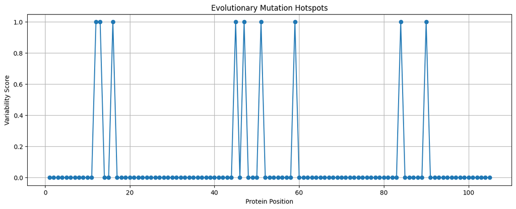

```python
# ============================================================
# STEP 16 — MUTATION HOTSPOT ANALYSIS
# ============================================================

import matplotlib.pyplot as plt

print("=" * 90)
print("Mutation Hotspot Analysis")
print("=" * 90)

# ------------------------------------------------------------
# COUNT MUTATIONS PER POSITION
# ------------------------------------------------------------

mutation_counts = []

alignment_length = len(ancestral_sequence)

for position in range(alignment_length):

    residues = []

    for sequence in protein_sequences.values():

        residues.append(sequence[position])

    unique_residues = set(residues)

    # --------------------------------------------------------
    # NUMBER OF UNIQUE RESIDUES
    # --------------------------------------------------------

    variability_score = len(unique_residues) - 1

    mutation_counts.append(variability_score)

# ============================================================
# DISPLAY VARIABLE POSITIONS
# ============================================================

print("\nVariable Positions:\n")

for i, value in enumerate(mutation_counts):

    if value > 0:

        print(

            f"Position {i+1} "

            f"→ Variability Score = {value}"

        )

# ============================================================
# VISUALIZATION
# ============================================================

plt.figure(figsize=(14, 5))

plt.plot(

    range(1, alignment_length + 1),

    mutation_counts,

    marker='o'

)

plt.xlabel("Protein Position")

plt.ylabel("Variability Score")

plt.title("Evolutionary Mutation Hotspots")

plt.grid(True)

plt.show()
```

# Step 17 — Evolutionary State Modeling

### Goal

Model evolutionary conservation states across protein positions.

### Why

Evolutionary sequences contain regions with different mutation behaviors.

Some regions are:

- highly conserved
- mutation tolerant

This introduces the concept of hidden evolutionary states.

### States

- Conserved State
- Variable State

### Output

State assignment for each protein position.

```python
# ============================================================
# STEP 17 — EVOLUTIONARY STATE MODELING
# ============================================================

print("=" * 90)
print("Evolutionary State Modeling")
print("=" * 90)

alignment_length = len(ancestral_sequence)

state_sequence = []

# ------------------------------------------------------------
# CLASSIFY POSITIONS
# ------------------------------------------------------------

for position in range(alignment_length):

    residues = []

    for sequence in protein_sequences.values():

        residues.append(sequence[position])

    unique_residues = set(residues)

    # --------------------------------------------------------
    # STATE ASSIGNMENT
    # --------------------------------------------------------

    if len(unique_residues) == 1:

        state = "C"

    else:

        state = "V"

    state_sequence.append(state)

# ============================================================
# DISPLAY STATES
# ============================================================

print("\nPosition-wise Evolutionary States:\n")

for i, state in enumerate(state_sequence):

    print(

        f"Position {i+1:>3} : {state}"

    )

# ============================================================
# STATE SUMMARY
# ============================================================

print("\n" + "=" * 90)
print("State Summary")
print("=" * 90)

conserved_count = state_sequence.count("C")

variable_count = state_sequence.count("V")

print(f"Conserved States : {conserved_count}")

print(f"Variable States  : {variable_count}")

# ============================================================
# VISUAL STATE REPRESENTATION
# ============================================================

print("\nState Sequence:\n")

print("".join(state_sequence))
```

```
==========================================================================================
Evolutionary State Modeling
==========================================================================================

Position-wise Evolutionary States:

Position   1 : C
Position   2 : C
Position   3 : C
Position   4 : C
Position   5 : C
Position   6 : C
Position   7 : C
Position   8 : C
Position   9 : C
Position  10 : C
Position  11 : C
Position  12 : V
Position  13 : V
Position  14 : C
Position  15 : C
Position  16 : V
Position  17 : C
Position  18 : C
Position  19 : C
Position  20 : C
Position  21 : C
Position  22 : C
Position  23 : C
Position  24 : C
Position  25 : C
Position  26 : C
Position  27 : C
Position  28 : C
Position  29 : C
Position  30 : C
Position  31 : C
Position  32 : C
Position  33 : C
Position  34 : C
```

[output cut: 66 more lines]

```
Position 101 : C
Position 102 : C
Position 103 : C
Position 104 : C
Position 105 : C

==========================================================================================
State Summary
==========================================================================================
Conserved States : 96
Variable States  : 9

State Sequence:

CCCCCCCCCCCVVCCVCCCCCCCCCCCCCCCCCCCCCCCCCCCCVCVCCCVCCCCCCCVCCCCCCCCCCCCCCCCCCCCCCCCVCCCCCVCCCCCCCCCCCCCCC
```

# Step 18 — Evolutionary State Transition Modeling

### Goal

Estimate transition probabilities between evolutionary states.

### Why

Evolutionary regions do not change randomly.

Conserved and variable regions transition according to evolutionary constraints.

### Transition Types

- Conserved → Conserved
- Conserved → Variable
- Variable → Conserved
- Variable → Variable

### Output

State transition probabilities.

```python
# ============================================================
# STEP 18 — STATE TRANSITION MODELING
# ============================================================

print("=" * 90)
print("Evolutionary State Transition Analysis")
print("=" * 90)

# ------------------------------------------------------------
# INITIALIZE TRANSITION COUNTS
# ------------------------------------------------------------

transitions = {

    "C->C": 0,
    "C->V": 0,
    "V->C": 0,
    "V->V": 0
}

# ------------------------------------------------------------
# COUNT TRANSITIONS
# ------------------------------------------------------------

for i in range(len(state_sequence) - 1):

    current_state = state_sequence[i]

    next_state = state_sequence[i + 1]

    transition = f"{current_state}->{next_state}"

    transitions[transition] += 1

# ============================================================
# DISPLAY TRANSITION COUNTS
# ============================================================

print("\nTransition Counts:\n")

for transition, count in transitions.items():

    print(f"{transition} : {count}")

# ============================================================
# COMPUTE TRANSITION PROBABILITIES
# ============================================================

print("\n" + "=" * 90)
print("Transition Probabilities")
print("=" * 90)

# ------------------------------------------------------------
# TOTAL OUTGOING TRANSITIONS
# ------------------------------------------------------------

total_C = transitions["C->C"] + transitions["C->V"]

total_V = transitions["V->C"] + transitions["V->V"]

# ------------------------------------------------------------
# PROBABILITIES
# ------------------------------------------------------------

P_CC = transitions["C->C"] / total_C
P_CV = transitions["C->V"] / total_C

P_VC = transitions["V->C"] / total_V
P_VV = transitions["V->V"] / total_V

# ------------------------------------------------------------
# DISPLAY RESULTS
# ------------------------------------------------------------

print(f"P(C → C) = {P_CC:.4f}")

print(f"P(C → V) = {P_CV:.4f}")

print(f"P(V → C) = {P_VC:.4f}")

print(f"P(V → V) = {P_VV:.4f}")
```

```
==========================================================================================
Evolutionary State Transition Analysis
==========================================================================================

Transition Counts:

C->C : 87
C->V : 8
V->C : 8
V->V : 1

==========================================================================================
Transition Probabilities
==========================================================================================
P(C → C) = 0.9158
P(C → V) = 0.0842
P(V → C) = 0.8889
P(V → V) = 0.1111
```

# Step 19 — Emission Probability Estimation

### Goal

Estimate amino acid emission probabilities for evolutionary states.

### Why

In Hidden Markov Models, hidden states generate observable outputs.

Here:

- hidden states = evolutionary conservation states
- observations = amino acid residues

### Objective

Estimate how residues are distributed under:

- conserved states
- variable states

### Output

Residue emission probabilities for each evolutionary state.

```python
# ============================================================
# STEP 19 — EMISSION PROBABILITY ESTIMATION
# ============================================================

from collections import defaultdict

print("=" * 90)
print("Emission Probability Estimation")
print("=" * 90)

# ------------------------------------------------------------
# STORE EMISSIONS
# ------------------------------------------------------------

state_emissions = {

    "C": [],
    "V": []
}

# ------------------------------------------------------------
# COLLECT RESIDUES BY STATE
# ------------------------------------------------------------

for position in range(len(state_sequence)):

    state = state_sequence[position]

    residues = []

    for sequence in protein_sequences.values():

        residues.append(sequence[position])

    # --------------------------------------------------------
    # STORE RESIDUES
    # --------------------------------------------------------

    state_emissions[state].extend(residues)

# ============================================================
# COMPUTE EMISSION PROBABILITIES
# ============================================================

for state in ["C", "V"]:

    print("\n" + "=" * 90)

    print(f"State : {state}")

    print("=" * 90)

    residue_counts = Counter(

        state_emissions[state]

    )

    total = sum(residue_counts.values())

    # --------------------------------------------------------
    # DISPLAY PROBABILITIES
    # --------------------------------------------------------

    for residue, count in sorted(residue_counts.items()):

        probability = count / total

        print(

            f"P({residue} | {state}) = "
            f"{probability:.4f}"

        )
```

```
==========================================================================================
Emission Probability Estimation
==========================================================================================

==========================================================================================
State : C
==========================================================================================
P(A | C) = 0.0521
P(C | C) = 0.0208
P(D | C) = 0.0312
P(E | C) = 0.0729
P(F | C) = 0.0312
P(G | C) = 0.1354
P(H | C) = 0.0312
P(I | C) = 0.0625
P(K | C) = 0.1875
P(L | C) = 0.0625
P(M | C) = 0.0312
P(N | C) = 0.0521
P(P | C) = 0.0312
P(Q | C) = 0.0208
P(R | C) = 0.0208
P(S | C) = 0.0104
P(T | C) = 0.0729
P(V | C) = 0.0208
P(W | C) = 0.0104
P(Y | C) = 0.0417

==========================================================================================
State : V
==========================================================================================
P(A | V) = 0.2000
P(D | V) = 0.0444
P(E | V) = 0.0667
P(F | V) = 0.0444
P(G | V) = 0.0444
P(I | V) = 0.1333
P(M | V) = 0.0667
P(P | V) = 0.0667
P(Q | V) = 0.0444
P(S | V) = 0.0667
P(T | V) = 0.0444
P(V | V) = 0.1111
P(Y | V) = 0.0667
```

# Step 20 — Ancestral Reconstruction Confidence Scoring

### Goal

Estimate confidence levels for ancestral residue predictions.

### Why

Not all ancestral predictions are equally reliable.

Highly conserved positions provide stronger evolutionary confidence than variable positions.

### Objective

Assign confidence scores to ancestral residue predictions.

### Output

Position-wise ancestral confidence estimates.

```python
# ============================================================
# STEP 20 — ANCESTRAL CONFIDENCE SCORING
# ============================================================

print("=" * 90)
print("Ancestral Reconstruction Confidence")
print("=" * 90)

confidence_scores = []

# ------------------------------------------------------------
# POSITION-WISE CONFIDENCE ANALYSIS
# ------------------------------------------------------------

for position in range(len(ancestral_sequence)):

    residues = []

    for sequence in protein_sequences.values():

        residues.append(sequence[position])

    residue_counts = Counter(residues)

    total = sum(residue_counts.values())

    # --------------------------------------------------------
    # MOST COMMON RESIDUE
    # --------------------------------------------------------

    best_residue, best_count = (

        residue_counts.most_common(1)[0]

    )

    confidence = best_count / total

    confidence_scores.append(confidence)

    # --------------------------------------------------------
    # DISPLAY RESULTS
    # --------------------------------------------------------

    print(

        f"Position {position + 1:>3} | "

        f"Residue = {best_residue} | "

        f"Confidence = {confidence:.2f}"

    )

# ============================================================
# SUMMARY
# ============================================================

print("\n" + "=" * 90)
print("Confidence Summary")
print("=" * 90)

average_confidence = sum(confidence_scores) / len(confidence_scores)

print(

    f"Average Confidence : "
    f"{average_confidence:.4f}"

)

high_confidence = sum(

    1 for c in confidence_scores

    if c >= 0.8

)

print(

    f"High Confidence Positions : "
    f"{high_confidence}"

)

print(

    f"Low Variability Positions : "
    f"{len(ancestral_sequence) - len(variable_positions)}"

)
```

```
==========================================================================================
Ancestral Reconstruction Confidence
==========================================================================================
Position   1 | Residue = M | Confidence = 1.00
Position   2 | Residue = G | Confidence = 1.00
Position   3 | Residue = D | Confidence = 1.00
Position   4 | Residue = V | Confidence = 1.00
Position   5 | Residue = E | Confidence = 1.00
Position   6 | Residue = K | Confidence = 1.00
Position   7 | Residue = G | Confidence = 1.00
Position   8 | Residue = K | Confidence = 1.00
Position   9 | Residue = K | Confidence = 1.00
Position  10 | Residue = I | Confidence = 1.00
Position  11 | Residue = F | Confidence = 1.00
Position  12 | Residue = I | Confidence = 0.60
Position  13 | Residue = M | Confidence = 0.60
Position  14 | Residue = K | Confidence = 1.00
Position  15 | Residue = C | Confidence = 1.00
Position  16 | Residue = S | Confidence = 0.60
Position  17 | Residue = Q | Confidence = 1.00
Position  18 | Residue = C | Confidence = 1.00
Position  19 | Residue = H | Confidence = 1.00
Position  20 | Residue = T | Confidence = 1.00
Position  21 | Residue = V | Confidence = 1.00
Position  22 | Residue = E | Confidence = 1.00
Position  23 | Residue = K | Confidence = 1.00
Position  24 | Residue = G | Confidence = 1.00
Position  25 | Residue = G | Confidence = 1.00
Position  26 | Residue = K | Confidence = 1.00
Position  27 | Residue = H | Confidence = 1.00
Position  28 | Residue = K | Confidence = 1.00
Position  29 | Residue = T | Confidence = 1.00
Position  30 | Residue = G | Confidence = 1.00
Position  31 | Residue = P | Confidence = 1.00
Position  32 | Residue = N | Confidence = 1.00
Position  33 | Residue = L | Confidence = 1.00
Position  34 | Residue = H | Confidence = 1.00
Position  35 | Residue = G | Confidence = 1.00
Position  36 | Residue = L | Confidence = 1.00
Position  37 | Residue = F | Confidence = 1.00
```

[output cut: 60 more lines]

```
Position  98 | Residue = Y | Confidence = 1.00
Position  99 | Residue = L | Confidence = 1.00
Position 100 | Residue = K | Confidence = 1.00
Position 101 | Residue = K | Confidence = 1.00
Position 102 | Residue = A | Confidence = 1.00
Position 103 | Residue = T | Confidence = 1.00
Position 104 | Residue = N | Confidence = 1.00
Position 105 | Residue = E | Confidence = 1.00

==========================================================================================
Confidence Summary
==========================================================================================
Average Confidence : 0.9657
High Confidence Positions : 96
Low Variability Positions : 96
```

# Step 21 — Evolutionary Sequence Simulation

### Goal

Simulate evolutionary mutations across generations.

### Why

Evolution occurs through gradual accumulation of mutations over time.

Using probabilistic mutation models, we can simulate how ancestral sequences may evolve into descendant variants.

### Objective

Generate simulated evolutionary descendants from the reconstructed ancestral sequence.

### Output

Simulated evolved protein sequences across generations.

```python
# ============================================================
# STEP 21 — EVOLUTIONARY SEQUENCE SIMULATION
# ============================================================

import random

print("=" * 90)
print("Evolutionary Sequence Simulation")
print("=" * 90)

# ------------------------------------------------------------
# AMINO ACID POOL
# ------------------------------------------------------------

amino_acids = list(

    "ACDEFGHIKLMNPQRSTVWY"

)

# ------------------------------------------------------------
# MUTATION RATE
# ------------------------------------------------------------

mutation_rate = 0.05

# ------------------------------------------------------------
# NUMBER OF GENERATIONS
# ------------------------------------------------------------

num_generations = 10

# ------------------------------------------------------------
# START WITH ANCESTRAL SEQUENCE
# ------------------------------------------------------------

current_sequence = ancestral_sequence

# ------------------------------------------------------------
# STORE EVOLUTION HISTORY
# ------------------------------------------------------------

evolution_history = [

    current_sequence

]

# ============================================================
# EVOLUTION SIMULATION
# ============================================================

for generation in range(1, num_generations + 1):

    new_sequence = ""

    mutations = 0

    # --------------------------------------------------------
    # POSITION-WISE EVOLUTION
    # --------------------------------------------------------

    for residue in current_sequence:

        # ----------------------------------------------------
        # MUTATION EVENT
        # ----------------------------------------------------

        if random.random() < mutation_rate:

            possible_mutations = [

                aa for aa in amino_acids

                if aa != residue
            ]

            mutated_residue = random.choice(

                possible_mutations

            )

            new_sequence += mutated_residue

            mutations += 1

        else:

            new_sequence += residue

    # --------------------------------------------------------
    # UPDATE CURRENT SEQUENCE
    # --------------------------------------------------------

    current_sequence = new_sequence

    evolution_history.append(current_sequence)

    # --------------------------------------------------------
    # DISPLAY GENERATION SUMMARY
    # --------------------------------------------------------

    print(

        f"\nGeneration {generation}"

    )

    print(

        f"Mutations Introduced : {mutations}"

    )

    print(

        f"Sequence Preview     : "
        f"{new_sequence[:60]}..."
    )
```

```
==========================================================================================
Evolutionary Sequence Simulation
==========================================================================================

Generation 1
Mutations Introduced : 2
Sequence Preview     : MGDVEKGKKIFIMKCSQCHMVEKGGKHKTGPNLHGLFGRKTGQAPGYSYTAWNKNKGIIW...

Generation 2
Mutations Introduced : 4
Sequence Preview     : MGDVEKGKKIFIMKCSQCHMVEKGGKHKTGPNLHGLFGRKTGQAPGYSYTAWNKNKGIWW...

Generation 3
Mutations Introduced : 6
Sequence Preview     : MGDVENGKKIFIMKTSQCHMVIKGGKHKTGPKLHGLFGRKTGQAPWYSYTAWNKNKGIWW...

Generation 4
Mutations Introduced : 4
Sequence Preview     : MGDVENGKKIFIMKTSQCHMVIKGGKHKTGPKLHGLFGRKTGQAPWYYYNAWNKNKGIWW...

Generation 5
Mutations Introduced : 5
Sequence Preview     : MGDVENGKKIFIMKTSQCHMWIKGGKHKTGPKLHGLFGRKTGQAPWYYYNNWNKNKGIHW...

Generation 6
Mutations Introduced : 5
Sequence Preview     : MGDVENGKKIFIMKTSQCHMWIKGGKHKTGPKLHGLFSRKLGQAPWYYYNNWNKNKGIHW...

Generation 7
Mutations Introduced : 4
Sequence Preview     : MGDVENGKKIFIMKTSQCHMWIKGGKHKTGPKLHGLFSRKLGQAPWYYYNNWNKNKGIHW...

Generation 8
Mutations Introduced : 6
Sequence Preview     : MNDVENGKKIFIMKTSQCHSWIKGGKHKTGPKLHGLFSRKLGQATWYYYNNWNKNKGIHR...

Generation 9
Mutations Introduced : 5
Sequence Preview     : MNDVCNGKKIFIMKTSQCHSWIPGGKHKTGPKLHGLFSRKLGQATWYYYNNWNKNKGIHR...

Generation 10
Mutations Introduced : 4
Sequence Preview     : MNDVCNGKKIFIMKTSQCHSWIPGGKHKTGPKLHGLFSRKLGQATWKYYNFWNKNVGIHR...
```

# Step 22 — State-Aware Evolutionary Simulation

### Goal

Simulate evolution using position-specific mutation behavior.

### Why

Biological evolution is not uniform across protein positions.

Conserved regions mutate less frequently than variable regions.

### Method

Mutation rates are assigned based on evolutionary state:

- conserved positions → low mutation probability
- variable positions → higher mutation probability

### Output

Biologically informed evolutionary simulation.

```python
# ============================================================
# STEP 22 — STATE-AWARE EVOLUTIONARY SIMULATION
# ============================================================

import random

print("=" * 90)
print("State-Aware Evolutionary Simulation")
print("=" * 90)

# ------------------------------------------------------------
# AMINO ACID POOL
# ------------------------------------------------------------

amino_acids = list(

    "ACDEFGHIKLMNPQRSTVWY"

)

# ------------------------------------------------------------
# STATE-SPECIFIC MUTATION RATES
# ------------------------------------------------------------

mutation_rates = {

    "C": 0.01,   # conserved positions

    "V": 0.20    # variable positions
}

# ------------------------------------------------------------
# SIMULATION SETTINGS
# ------------------------------------------------------------

num_generations = 10

current_sequence = ancestral_sequence

simulation_history = [

    current_sequence

]

# ============================================================
# EVOLUTION LOOP
# ============================================================

for generation in range(1, num_generations + 1):

    new_sequence = ""

    mutations = 0

    # --------------------------------------------------------
    # POSITION-WISE EVOLUTION
    # --------------------------------------------------------

    for position in range(len(current_sequence)):

        residue = current_sequence[position]

        state = state_sequence[position]

        mutation_probability = (

            mutation_rates[state]

        )

        # ----------------------------------------------------
        # MUTATION EVENT
        # ----------------------------------------------------

        if random.random() < mutation_probability:

            possible_mutations = [

                aa for aa in amino_acids

                if aa != residue
            ]

            mutated_residue = random.choice(

                possible_mutations

            )

            new_sequence += mutated_residue

            mutations += 1

        else:

            new_sequence += residue

    # --------------------------------------------------------
    # UPDATE SEQUENCE
    # --------------------------------------------------------

    current_sequence = new_sequence

    simulation_history.append(

        current_sequence

    )

    # --------------------------------------------------------
    # DISPLAY RESULTS
    # --------------------------------------------------------

    print(f"\nGeneration {generation}")

    print(

        f"Mutations Introduced : "
        f"{mutations}"

    )

    print(

        f"Sequence Preview     : "
        f"{new_sequence[:60]}..."
    )
```

```
==========================================================================================
State-Aware Evolutionary Simulation
==========================================================================================

Generation 1
Mutations Introduced : 1
Sequence Preview     : MGDVEKGKKIFIMKCSQCHTVEKGGKHKTGPNLHGLFGRKTGQAPGYSYTAANKNKGIVW...

Generation 2
Mutations Introduced : 5
Sequence Preview     : MGDVEKGKKIFILKCSQCHTVEKGGKHKTGPNLHGLFGRKTGQAPGYSYTAANKNKGIKW...

Generation 3
Mutations Introduced : 4
Sequence Preview     : MGDVEKGPKIFPVKCSQCHTVEKGGKHKTGPNLHGLFGRKTGQAPGYSYTIANKNKGIKW...

Generation 4
Mutations Introduced : 2
Sequence Preview     : MGDVEKGPKIFPKKCSQCHTVEKGGKHKTGPNLHGLFGRKTGQAPGDSYTIANKNKGIKW...

Generation 5
Mutations Introduced : 2
Sequence Preview     : MGDVEKGPKIFPKKCSQCHTVEKGGKHKTGPNLHGLFGRKTGQAPGDSETIANKNKGIVW...

Generation 6
Mutations Introduced : 4
Sequence Preview     : MGDVEKGPKIFSKKCSQCHTVEKGGKHKTGPNLHGLFGRKTGQAPGDSETWANKNKGIVW...

Generation 7
Mutations Introduced : 3
Sequence Preview     : MGDVEKGPKIFSKKCSQCHTVEKGGKHKTGPNLQGLFGRKTGQAPGDSETLANKNKGIVW...

Generation 8
Mutations Introduced : 2
Sequence Preview     : MGDVEKGPKIFSKKCSQCHAVEKGGKHKTGPNLQGLFGRKTGQAPGDSETLANKNKGIVW...

Generation 9
Mutations Introduced : 3
Sequence Preview     : MGDVEKGPKIFSKKCSQCHAVEKGGKHKTGPNLQGLFGRKTGQAPGPSETLANKNKGIVW...

Generation 10
Mutations Introduced : 3
Sequence Preview     : MGDVEKGPKIFSKKCSQCHAVEKGGKHKTGPNLQGLFGRKTGQAPGPSETLANKNKGIKW...
```

# Step 23 — Biochemically Weighted Evolutionary Simulation

### Goal

Simulate biologically realistic mutations using amino acid similarity relationships.

### Why

Real evolutionary mutations are not uniformly random.

Biochemically similar substitutions occur more frequently than radical substitutions.

### Concept

Mutations are biased toward chemically similar amino acids.

### Output

More biologically realistic evolutionary simulations.

```python
# ============================================================
# STEP 23 — BIOCHEMICALLY WEIGHTED MUTATION SIMULATION
# ============================================================

import random

print("=" * 90)
print("Biochemically Weighted Evolution Simulation")
print("=" * 90)

# ------------------------------------------------------------
# BIOCHEMICAL SUBSTITUTION GROUPS
# ------------------------------------------------------------

substitution_preferences = {

    # Hydrophobic
    'A': ['V', 'L', 'I', 'G'],
    'V': ['I', 'L', 'A'],
    'I': ['V', 'L', 'M'],
    'L': ['I', 'V', 'M'],
    'M': ['L', 'I'],

    # Polar
    'S': ['T', 'N', 'Q'],
    'T': ['S', 'N'],
    'N': ['Q', 'S'],
    'Q': ['N', 'E'],

    # Charged
    'K': ['R', 'H'],
    'R': ['K', 'H'],
    'D': ['E'],
    'E': ['D', 'Q'],

    # Aromatic
    'F': ['Y', 'W'],
    'Y': ['F', 'W'],

    # Special cases
    'G': ['A'],
    'P': ['A'],
    'C': ['S'],
    'H': ['K', 'R'],
    'W': ['F', 'Y']
}

# ------------------------------------------------------------
# MUTATION SETTINGS
# ------------------------------------------------------------

mutation_rates = {

    "C": 0.01,

    "V": 0.20
}

num_generations = 10

current_sequence = ancestral_sequence

# ============================================================
# EVOLUTION LOOP
# ============================================================

for generation in range(1, num_generations + 1):

    new_sequence = ""

    mutations = 0

    # --------------------------------------------------------
    # POSITION-WISE EVOLUTION
    # --------------------------------------------------------

    for position in range(len(current_sequence)):

        residue = current_sequence[position]

        state = state_sequence[position]

        mutation_probability = (

            mutation_rates[state]

        )

        # ----------------------------------------------------
        # MUTATION EVENT
        # ----------------------------------------------------

        if random.random() < mutation_probability:

            # -----------------------------------------------
            # BIOCHEMICALLY PREFERRED MUTATIONS
            # -----------------------------------------------

            if residue in substitution_preferences:

                mutation_pool = (

                    substitution_preferences[residue]

                )

            else:

                mutation_pool = [

                    aa for aa in amino_acids

                    if aa != residue
                ]

            mutated_residue = random.choice(

                mutation_pool

            )

            new_sequence += mutated_residue

            mutations += 1

        else:

            new_sequence += residue

    # --------------------------------------------------------
    # UPDATE SEQUENCE
    # --------------------------------------------------------

    current_sequence = new_sequence

    # --------------------------------------------------------
    # DISPLAY RESULTS
    # --------------------------------------------------------

    print(f"\nGeneration {generation}")

    print(

        f"Mutations Introduced : "
        f"{mutations}"

    )

    print(

        f"Sequence Preview     : "
        f"{new_sequence[:60]}..."
    )
```

```
==========================================================================================
Biochemically Weighted Evolution Simulation
==========================================================================================

Generation 1
Mutations Introduced : 0
Sequence Preview     : MGDVEKGKKIFIMKCSQCHTVEKGGKHKTGPNLHGLFGRKTGQAPGYSYTAANKNKGIIW...

Generation 2
Mutations Introduced : 1
Sequence Preview     : MGDVEKGKKIFIMKCSQCHTVEKGGKHKTGPNLHGLFGRKTGQAPGYSYTAANKNKGIIF...

Generation 3
Mutations Introduced : 3
Sequence Preview     : MGDVEKGKKIFIMKCSQCHTVEKGGKHKTGPNLHGLFGRKTGQAPGWSYTAANKNKGILF...

Generation 4
Mutations Introduced : 2
Sequence Preview     : MGDVEKGRKIFLMKCSQCHTVEKGGKHKTGPNLHGLFGRKTGQAPGWSYTAANKNKGILF...

Generation 5
Mutations Introduced : 4
Sequence Preview     : MGDVEKGRKIFIMKCSQCHTVEKGGKHKTGPNLHGLFGRKTGQAPGWSFTAANKNKGILF...

Generation 6
Mutations Introduced : 1
Sequence Preview     : MGDVEKGRKIFIMKCSQCHTVEKGGKHKTGPNLHGLFGRKTGQAPGYSFTAANKNKGILF...

Generation 7
Mutations Introduced : 3
Sequence Preview     : MGDVEKGRKIFVMKCSQCHTVEKGGKHKTGPNLHGLFGRKTGQAPGYSFTAANKNKGIIF...

Generation 8
Mutations Introduced : 1
Sequence Preview     : MGDVEKGRKIFVMKCNQCHTVEKGGKHKTGPNLHGLFGRKTGQAPGYSFTAANKNKGIIF...

Generation 9
Mutations Introduced : 4
Sequence Preview     : MGDVEKGRKIFVMKCSQCHTVEKGGKHKTGPNLHGLFGRKTGQAPGYSFTGANKNKGIIF...

Generation 10
Mutations Introduced : 5
Sequence Preview     : MGDAEKGRKIFVMKCSQCHTVEKGGKHKTGPNLHGLFGRKTGQAAGYSFTGANKNKGIIF...
```

# Step 24 — Evolutionary Fitness Evaluation

### Goal

Estimate how evolutionarily stable simulated sequences remain over time.

### Why

Not all mutations are equally tolerated.

As mutations accumulate, sequences may drift away from the ancestral functional form.

### Concept

Sequences that preserve conserved regions are considered more evolutionarily stable.

### Output

Fitness scores across generations.

```
==========================================================================================
Evolutionary Fitness Evaluation
==========================================================================================

Generation-wise Fitness:

Generation  0 | Fitness = 1.0000
Generation  1 | Fitness = 0.9952
Generation  2 | Fitness = 0.9714
Generation  3 | Fitness = 0.9524
Generation  4 | Fitness = 0.9476
Generation  5 | Fitness = 0.9381
Generation  6 | Fitness = 0.9286
Generation  7 | Fitness = 0.9095
Generation  8 | Fitness = 0.9000
Generation  9 | Fitness = 0.8905
Generation 10 | Fitness = 0.8714
```

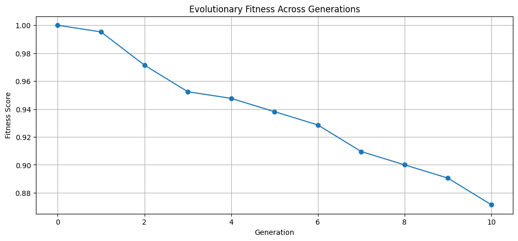

```python
# ============================================================
# STEP 24 — EVOLUTIONARY FITNESS EVALUATION
# ============================================================

print("=" * 90)
print("Evolutionary Fitness Evaluation")
print("=" * 90)

# ------------------------------------------------------------
# FITNESS FUNCTION
# ------------------------------------------------------------

def compute_fitness(sequence, reference, states):

    score = 0

    max_score = 0

    # --------------------------------------------------------
    # POSITION-WISE FITNESS
    # --------------------------------------------------------

    for i in range(len(sequence)):

        state = states[i]

        max_score += 1

        # ----------------------------------------------------
        # CONSERVED POSITIONS
        # HIGHER PENALTY FOR MUTATION
        # ----------------------------------------------------

        if state == "C":

            if sequence[i] == reference[i]:

                score += 1

        # ----------------------------------------------------
        # VARIABLE POSITIONS
        # PARTIAL FLEXIBILITY
        # ----------------------------------------------------

        else:

            if sequence[i] == reference[i]:

                score += 1

            else:

                score += 0.5

    return score / max_score

# ============================================================
# EVALUATE SIMULATION HISTORY
# ============================================================

fitness_scores = []

print("\nGeneration-wise Fitness:\n")

for generation, sequence in enumerate(simulation_history):

    fitness = compute_fitness(

        sequence,

        ancestral_sequence,

        state_sequence

    )

    fitness_scores.append(fitness)

    print(

        f"Generation {generation:>2} "

        f"| Fitness = {fitness:.4f}"

    )

# ============================================================
# FITNESS VISUALIZATION
# ============================================================

plt.figure(figsize=(12, 5))

plt.plot(

    range(len(fitness_scores)),

    fitness_scores,

    marker='o'

)

plt.xlabel("Generation")

plt.ylabel("Fitness Score")

plt.title("Evolutionary Fitness Across Generations")

plt.grid(True)

plt.show()
```

# Step 25 — Selection-Based Evolutionary Simulation

### Goal

Simulate natural selection during evolutionary progression.

### Why

In biological evolution, not all mutations survive.

Sequences with lower fitness are less likely to persist across generations.

### Concept

Only sequences above a fitness threshold survive evolutionary selection.

### Output

Fitness-filtered evolutionary trajectories.

```
==========================================================================================
Selection-Based Evolutionary Simulation
==========================================================================================

Generation 1
Fitness : 0.9667
Status   : SURVIVED

Generation 2
Fitness : 0.9286
Status   : SURVIVED

Generation 3
Fitness : 0.9238
Status   : SURVIVED

Generation 4
Fitness : 0.9000
Status   : SURVIVED

Generation 5
Fitness : 0.8762
Status   : REMOVED

Generation 6
Fitness : 0.9048
Status   : SURVIVED

Generation 7
Fitness : 0.8952
Status   : REMOVED

Generation 8
Fitness : 0.8810
Status   : REMOVED

Generation 9
Fitness : 0.8810
Status   : REMOVED

```

[output cut: 28 more lines]

```
Generation 17
Fitness : 0.8905
Status   : REMOVED

Generation 18
Fitness : 0.8810
Status   : REMOVED

Generation 19
Fitness : 0.8905
Status   : REMOVED

Generation 20
Fitness : 0.8810
Status   : REMOVED
```

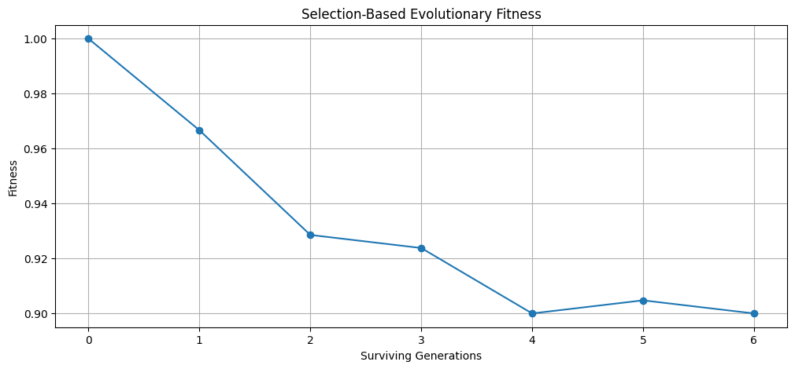

```python
# ============================================================
# STEP 25 — SELECTION-BASED EVOLUTION
# ============================================================

import random

print("=" * 90)
print("Selection-Based Evolutionary Simulation")
print("=" * 90)

# ------------------------------------------------------------
# FITNESS THRESHOLD
# ------------------------------------------------------------

fitness_threshold = 0.90

# ------------------------------------------------------------
# MUTATION SETTINGS
# ------------------------------------------------------------

mutation_rates = {

    "C": 0.01,

    "V": 0.20
}

num_generations = 20

current_sequence = ancestral_sequence

selected_history = [

    current_sequence

]

fitness_history = [

    1.0
]

# ============================================================
# EVOLUTION LOOP
# ============================================================

for generation in range(1, num_generations + 1):

    new_sequence = ""

    # --------------------------------------------------------
    # MUTATION PROCESS
    # --------------------------------------------------------

    for position in range(len(current_sequence)):

        residue = current_sequence[position]

        state = state_sequence[position]

        mutation_probability = (

            mutation_rates[state]

        )

        # ----------------------------------------------------
        # MUTATION EVENT
        # ----------------------------------------------------

        if random.random() < mutation_probability:

            if residue in substitution_preferences:

                mutation_pool = (

                    substitution_preferences[residue]

                )

            else:

                mutation_pool = [

                    aa for aa in amino_acids

                    if aa != residue
                ]

            mutated_residue = random.choice(

                mutation_pool

            )

            new_sequence += mutated_residue

        else:

            new_sequence += residue

    # ========================================================
    # FITNESS EVALUATION
    # ========================================================

    fitness = compute_fitness(

        new_sequence,

        ancestral_sequence,

        state_sequence

    )

    # ========================================================
    # SELECTION STEP
    # ========================================================

    if fitness >= fitness_threshold:

        current_sequence = new_sequence

        selected_history.append(

            current_sequence

        )

        fitness_history.append(

            fitness

        )

        status = "SURVIVED"

    else:

        status = "REMOVED"

    # ========================================================
    # DISPLAY RESULTS
    # ========================================================

    print(

        f"\nGeneration {generation}"

    )

    print(

        f"Fitness : {fitness:.4f}"

    )

    print(

        f"Status   : {status}"

    )

# ============================================================
# VISUALIZE FITNESS TRAJECTORY
# ============================================================

plt.figure(figsize=(12, 5))

plt.plot(

    range(len(fitness_history)),

    fitness_history,

    marker='o'

)

plt.xlabel("Surviving Generations")

plt.ylabel("Fitness")

plt.title("Selection-Based Evolutionary Fitness")

plt.grid(True)

plt.show()
```

# Step 26 — Branching Evolutionary Simulation

### Goal

Simulate evolutionary divergence into multiple independent lineages.

### Why

Real evolution produces branching descendant populations rather than a single linear lineage.

### Concept

One ancestral sequence evolves into multiple independently mutating descendant branches.

### Output

Divergent evolutionary lineages over generations.

```python
# ============================================================
# STEP 26 — BRANCHING EVOLUTION SIMULATION
# ============================================================

import random

print("=" * 90)
print("Branching Evolutionary Simulation")
print("=" * 90)

# ------------------------------------------------------------
# NUMBER OF LINEAGES
# ------------------------------------------------------------

num_lineages = 3

# ------------------------------------------------------------
# GENERATIONS
# ------------------------------------------------------------

num_generations = 10

# ------------------------------------------------------------
# INITIALIZE LINEAGES
# ------------------------------------------------------------

lineages = {

    f"Lineage_{i+1}": ancestral_sequence

    for i in range(num_lineages)
}

# ============================================================
# EVOLUTION LOOP
# ============================================================

for generation in range(1, num_generations + 1):

    print("\n" + "=" * 70)

    print(f"Generation {generation}")

    print("=" * 70)

    updated_lineages = {}

    # --------------------------------------------------------
    # EVOLVE EACH LINEAGE
    # --------------------------------------------------------

    for lineage_name, sequence in lineages.items():

        evolved_sequence = ""

        mutations = 0

        for position in range(len(sequence)):

            residue = sequence[position]

            state = state_sequence[position]

            mutation_probability = (

                mutation_rates[state]

            )

            # ------------------------------------------------
            # MUTATION EVENT
            # ------------------------------------------------

            if random.random() < mutation_probability:

                if residue in substitution_preferences:

                    mutation_pool = (

                        substitution_preferences[residue]

                    )

                else:

                    mutation_pool = [

                        aa for aa in amino_acids

                        if aa != residue
                    ]

                mutated_residue = random.choice(

                    mutation_pool

                )

                evolved_sequence += mutated_residue

                mutations += 1

            else:

                evolved_sequence += residue

        # ----------------------------------------------------
        # STORE UPDATED LINEAGE
        # ----------------------------------------------------

        updated_lineages[lineage_name] = evolved_sequence

        # ----------------------------------------------------
        # FITNESS
        # ----------------------------------------------------

        fitness = compute_fitness(

            evolved_sequence,

            ancestral_sequence,

            state_sequence

        )

        # ----------------------------------------------------
        # DISPLAY RESULTS
        # ----------------------------------------------------

        print(

            f"\n{lineage_name}"

        )

        print(

            f"Mutations : {mutations}"

        )

        print(

            f"Fitness   : {fitness:.4f}"

        )

        print(

            f"Preview   : "
            f"{evolved_sequence[:50]}..."
        )

    # --------------------------------------------------------
    # UPDATE POPULATION
    # --------------------------------------------------------

    lineages = updated_lineages
```

```
==========================================================================================
Branching Evolutionary Simulation
==========================================================================================

======================================================================
Generation 1
======================================================================

Lineage_1
Mutations : 3
Fitness   : 0.9762
Preview   : MGDAEKGKKIFIMKCSQCHTVEKGGKHKTGPNLHGLFGRKTGQAAGYSYT...

Lineage_2
Mutations : 5
Fitness   : 0.9714
Preview   : MGDVEKGKKIFIMKCNQSHTVEKGGKHKTGPNLHGLFGRKTGQAAGFSYT...

Lineage_3
Mutations : 3
Fitness   : 0.9810
Preview   : MGDVEKGKKIFVMKCSQCHTVEKGGKHKTGPNMHGLFGRKTGQAPGWSYT...

======================================================================
Generation 2
======================================================================

Lineage_1
Mutations : 2
Fitness   : 0.9619
Preview   : MGDAEKGKKIFIMKCSQCHTVEKGGKHKTGPNLHGLFGRKTGQAAGYSYT...

Lineage_2
Mutations : 3
Fitness   : 0.9619
Preview   : MGDVEKGKKIFIMKCNQQHTVEKGGKHKTGPNLHALFGRKTGQAIGFSYT...

Lineage_3
Mutations : 5
Fitness   : 0.9571
```

[output cut: 138 more lines]

```

Lineage_1
Mutations : 3
Fitness   : 0.8952
Preview   : MGDAEKGKKIFVIKCEQCHTVEKGGKHKTGPNLHGLFGRKTGQGAGYSYT...

Lineage_2
Mutations : 7
Fitness   : 0.8619
Preview   : MGDVEKGKKIFILKCDQQHTLEKAGKHKTGANLHALFGRKTAQALAFSYT...

Lineage_3
Mutations : 1
Fitness   : 0.8571
Preview   : MGDVEKAKKIFIVKCTQCHTVEKGGKHKTGPNMHGLFGRKTGQIAAYSYT...
```

# Step 27 — Lineage Divergence Analysis

### Goal

Measure evolutionary divergence between simulated descendant lineages.

### Why

Independent evolutionary branches accumulate different mutations over time.

Quantifying divergence helps model:

- lineage separation
- phylogenetic relationships
- evolutionary distance accumulation

### Output

Pairwise divergence matrix between evolved lineages.

```python
# ============================================================
# STEP 27 — LINEAGE DIVERGENCE ANALYSIS
# ============================================================

print("=" * 90)
print("Lineage Divergence Analysis")
print("=" * 90)

lineage_names = list(lineages.keys())

# ------------------------------------------------------------
# CREATE DIVERGENCE MATRIX
# ------------------------------------------------------------

divergence_matrix = pd.DataFrame(

    index=lineage_names,

    columns=lineage_names

)

# ------------------------------------------------------------
# COMPUTE PAIRWISE DIVERGENCE
# ------------------------------------------------------------

for lineage_1 in lineage_names:

    for lineage_2 in lineage_names:

        seq1 = lineages[lineage_1]

        seq2 = lineages[lineage_2]

        differences = 0

        # ----------------------------------------------------
        # POSITION-WISE COMPARISON
        # ----------------------------------------------------

        for i in range(len(seq1)):

            if seq1[i] != seq2[i]:

                differences += 1

        divergence = differences / len(seq1)

        divergence_matrix.loc[

            lineage_1,

            lineage_2

        ] = round(divergence, 4)

# ============================================================
# DISPLAY RESULTS
# ============================================================

print("\nPairwise Lineage Divergence Matrix:\n")

display(divergence_matrix)
```

```
==========================================================================================
Lineage Divergence Analysis
==========================================================================================

Pairwise Lineage Divergence Matrix:
```

|  | Lineage_1 | Lineage_2 | Lineage_3 |
| --- | --- | --- | --- |
| Lineage_1 | 0.0 | 0.2571 | 0.2476 |
| Lineage_2 | 0.2571 | 0.0 | 0.2857 |
| Lineage_3 | 0.2476 | 0.2857 | 0.0 |

# Step 28 — Ancestral Reconstruction Validation

### Goal

Reconstruct the ancestral sequence from evolved descendant lineages.

### Why

This tests whether ancestral reconstruction methods can recover the original ancestral sequence after evolutionary divergence.

### Concept

Use evolved descendant sequences as observed modern species.

### Output

- reconstructed ancestor
- reconstruction accuracy
- recovery comparison with original ancestor

```python
# ============================================================
# STEP 28 — ANCESTRAL RECONSTRUCTION VALIDATION
# ============================================================

from collections import Counter

print("=" * 90)
print("Ancestral Reconstruction Validation")
print("=" * 90)

# ------------------------------------------------------------
# RECONSTRUCT ANCESTOR
# ------------------------------------------------------------

reconstructed_ancestor = ""

sequence_length = len(

    ancestral_sequence

)

# ------------------------------------------------------------
# POSITION-WISE RECONSTRUCTION
# ------------------------------------------------------------

for position in range(sequence_length):

    residues = []

    for lineage_sequence in lineages.values():

        residues.append(

            lineage_sequence[position]

        )

    residue_counts = Counter(

        residues

    )

    most_common = (

        residue_counts.most_common(1)[0][0]

    )

    reconstructed_ancestor += most_common

# ============================================================
# DISPLAY RESULTS
# ============================================================

print("\nReconstructed Ancestor:\n")

print(reconstructed_ancestor)

# ============================================================
# COMPARE TO ORIGINAL ANCESTOR
# ============================================================

matches = 0

differences = []

for i in range(sequence_length):

    original = ancestral_sequence[i]

    reconstructed = reconstructed_ancestor[i]

    if original == reconstructed:

        matches += 1

    else:

        differences.append(

            (i + 1, original, reconstructed)

        )

# ============================================================
# ACCURACY
# ============================================================

accuracy = matches / sequence_length

print("\n" + "=" * 90)
print("Reconstruction Accuracy")
print("=" * 90)

print(

    f"Accuracy : {accuracy:.4f}"

)

print(

    f"Recovered Positions : "
    f"{matches}/{sequence_length}"

)

# ============================================================
# DISPLAY DIFFERENCES
# ============================================================

print("\nDifferences:\n")

if len(differences) == 0:

    print("Perfect reconstruction.")

else:

    for diff in differences:

        pos, original, reconstructed = diff

        print(

            f"Position {pos} : "

            f"{original} → {reconstructed}"

        )
```

```
==========================================================================================
Ancestral Reconstruction Validation
==========================================================================================

Reconstructed Ancestor:

MGDVEKGKKIFIIKCEQCHTVEKGGKHKTGPNLHGLFGRKTGQGAAYSYTAANKNKGIVWGEDTLMEYLENPKKYIPGTKMIFIGIKKKEERADLIAYLKKATNE

==========================================================================================
Reconstruction Accuracy
==========================================================================================
Accuracy : 0.9333
Recovered Positions : 98/105

Differences:

Position 13 : M → I
Position 16 : S → E
Position 44 : A → G
Position 45 : P → A
Position 46 : G → A
Position 59 : I → V
Position 84 : V → I
```

- highly conserved positions are recoverable
- variable positions accumulate ambiguity
- evolutionary drift reduces reconstruction certainty

# Final Step — Evolutionary Reconstruction Assessment

### Goal

Summarize the effectiveness of the evolutionary reconstruction framework.

### Why

A final assessment helps evaluate:

- ancestral reconstruction quality
- evolutionary divergence effects
- reconstruction robustness
- conservation-driven stability

### Evaluation Areas

- ancestral recovery accuracy
- mutation accumulation
- evolutionary fitness decline
- lineage divergence
- conservation preservation

### Outcome

A complete computational evolutionary reconstruction framework integrating:

- ancestral inference
- probabilistic reconstruction
- evolutionary simulation
- selection-based dynamics
- lineage divergence analysis
- reconstruction validation

```python
# ============================================================
# FINAL EVOLUTIONARY RECONSTRUCTION ASSESSMENT
# ============================================================

print("=" * 90)
print("FINAL EVOLUTIONARY RECONSTRUCTION ASSESSMENT")
print("=" * 90)

# ============================================================
# RECONSTRUCTION ACCURACY
# ============================================================

reconstruction_accuracy = (

    matches / len(ancestral_sequence)

)

# ============================================================
# AVERAGE LINEAGE DIVERGENCE
# ============================================================

divergence_values = []

for i in range(len(lineage_names)):

    for j in range(i + 1, len(lineage_names)):

        divergence = float(

            divergence_matrix.iloc[i, j]

        )

        divergence_values.append(

            divergence

        )

average_divergence = (

    sum(divergence_values)

    / len(divergence_values)

)

# ============================================================
# FITNESS SUMMARY
# ============================================================

final_fitness_values = []

for lineage_sequence in lineages.values():

    fitness = compute_fitness(

        lineage_sequence,

        ancestral_sequence,

        state_sequence

    )

    final_fitness_values.append(

        fitness

    )

average_fitness = (

    sum(final_fitness_values)

    / len(final_fitness_values)

)

# ============================================================
# CONSERVATION STATISTICS
# ============================================================

conserved_positions = (

    state_sequence.count("C")

)

variable_positions_count = (

    state_sequence.count("V")

)

# ============================================================
# DISPLAY RESULTS
# ============================================================

print("\nReconstruction Accuracy")

print("-" * 40)

print(

    f"Recovered Positions : "
    f"{matches}/{len(ancestral_sequence)}"

)

print(

    f"Accuracy            : "
    f"{reconstruction_accuracy:.4f}"

)

# ------------------------------------------------------------

print("\nEvolutionary Divergence")

print("-" * 40)

print(

    f"Average Divergence : "
    f"{average_divergence:.4f}"

)

# ------------------------------------------------------------

print("\nEvolutionary Fitness")

print("-" * 40)

print(

    f"Average Lineage Fitness : "
    f"{average_fitness:.4f}"

)

# ------------------------------------------------------------

print("\nEvolutionary State Composition")

print("-" * 40)

print(

    f"Conserved Positions : "
    f"{conserved_positions}"

)

print(

    f"Variable Positions  : "
    f"{variable_positions_count}"

)

# ============================================================
# FINAL INTERPRETATION
# ============================================================

print("\n" + "=" * 90)
print("FINAL INTERPRETATION")
print("=" * 90)

if reconstruction_accuracy > 0.90:

    reconstruction_result = (

        "High ancestral recovery capability"

    )

elif reconstruction_accuracy > 0.75:

    reconstruction_result = (

        "Moderate ancestral recovery capability"

    )

else:

    reconstruction_result = (

        "Low ancestral recovery capability"

    )

print(

    f"\nReconstruction Assessment : "
    f"{reconstruction_result}"

)

if average_fitness > 0.90:

    fitness_result = (

        "Evolutionary stability preserved"

    )

else:

    fitness_result = (

        "Significant evolutionary degradation observed"

    )

print(

    f"Fitness Assessment        : "
    f"{fitness_result}"

)

if average_divergence > 0.20:

    divergence_result = (

        "Substantial lineage divergence detected"

    )

else:

    divergence_result = (

        "Limited lineage divergence observed"

    )

print(

    f"Divergence Assessment     : "
    f"{divergence_result}"

)

print("\nProject Conclusion:")

print(

    "The framework successfully integrated "
    "ancestral reconstruction, probabilistic "
    "reverse translation, evolutionary state "
    "modeling, mutation-driven evolution, "
    "selection pressure simulation, and "
    "lineage divergence analysis into a "
    "unified computational evolutionary system."

)
```

```
==========================================================================================
FINAL EVOLUTIONARY RECONSTRUCTION ASSESSMENT
==========================================================================================

Reconstruction Accuracy
----------------------------------------
Recovered Positions : 98/105
Accuracy            : 0.9333

Evolutionary Divergence
----------------------------------------
Average Divergence : 0.2635

Evolutionary Fitness
----------------------------------------
Average Lineage Fitness : 0.8714

Evolutionary State Composition
----------------------------------------
Conserved Positions : 96
Variable Positions  : 9

==========================================================================================
FINAL INTERPRETATION
==========================================================================================

Reconstruction Assessment : High ancestral recovery capability
Fitness Assessment        : Significant evolutionary degradation observed
Divergence Assessment     : Substantial lineage divergence detected

Project Conclusion:
The framework successfully integrated ancestral reconstruction, probabilistic reverse translation, evolutionary state modeling, mutation-driven evolution, selection pressure simulation, and lineage divergence analysis into a unified computational evolutionary system.
```

# Visualization — Phylogenetic Relationship Tree

### Purpose

Visualize evolutionary relationships between species based on sequence divergence.

### Interpretation

Closely related species cluster together, while distant species form separate evolutionary branches.

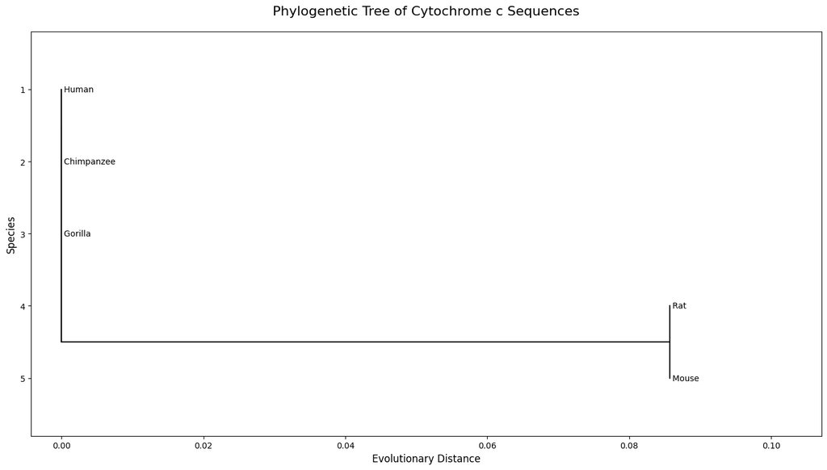

```python
# ============================================================
# IMPROVED PHYLOGENETIC TREE VISUALIZATION
# ============================================================

from Bio.Phylo.TreeConstruction import DistanceMatrix
from Bio.Phylo.TreeConstruction import DistanceTreeConstructor
from Bio import Phylo

import matplotlib.pyplot as plt

# ------------------------------------------------------------
# SPECIES NAMES
# ------------------------------------------------------------

species_names = [

    "Human",
    "Chimpanzee",
    "Gorilla",
    "Mouse",
    "Rat"
]

# ------------------------------------------------------------
# DISTANCE MATRIX
# ------------------------------------------------------------

matrix = [

    [0.0],

    [0.0, 0.0],

    [0.0, 0.0, 0.0],

    [0.0857, 0.0857, 0.0857, 0.0],

    [0.0857, 0.0857, 0.0857, 0.0, 0.0]
]

# ------------------------------------------------------------
# BUILD TREE
# ------------------------------------------------------------

dm = DistanceMatrix(

    species_names,

    matrix

)

constructor = DistanceTreeConstructor()

tree = constructor.nj(dm)

# ------------------------------------------------------------
# REMOVE INNER NODE LABELS
# ------------------------------------------------------------

for clade in tree.find_clades():

    if clade.name and clade.name.startswith("Inner"):

        clade.name = None

# ============================================================
# VISUALIZATION
# ============================================================

fig = plt.figure(

    figsize=(14, 8)

)

ax = fig.add_subplot(1, 1, 1)

Phylo.draw(

    tree,

    axes=ax,

    do_show=False,

    show_confidence=False

)

# ------------------------------------------------------------
# TITLE
# ------------------------------------------------------------

plt.title(

    "Phylogenetic Tree of Cytochrome c Sequences",

    fontsize=16,

    pad=20

)

# ------------------------------------------------------------
# IMPROVE SPACING
# ------------------------------------------------------------

plt.xlabel(

    "Evolutionary Distance",

    fontsize=12

)

plt.ylabel(

    "Species",

    fontsize=12

)

plt.tight_layout()

plt.show()
```

# Visualization — Lineage Divergence Heatmap

### Purpose

Visualize evolutionary divergence between simulated descendant lineages.

### Interpretation

Higher divergence values indicate greater evolutionary separation.

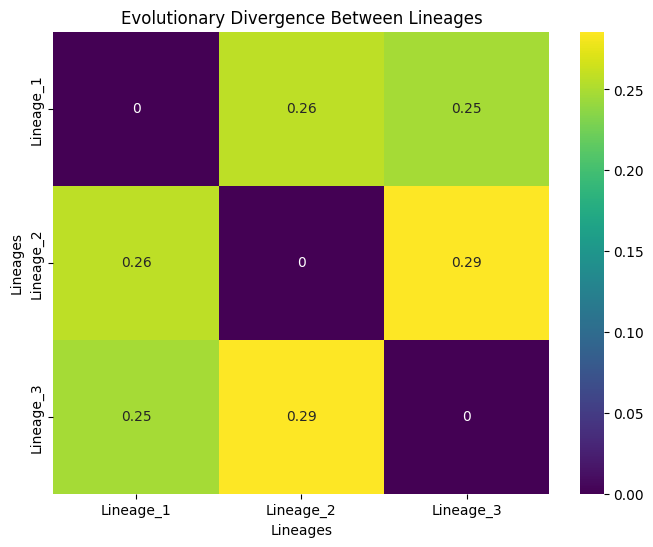

```python
# ============================================================
# LINEAGE DIVERGENCE HEATMAP
# ============================================================

plt.figure(figsize=(8, 6))

sns.heatmap(

    divergence_matrix.astype(float),

    annot=True,

    cmap="viridis"

)

plt.title(

    "Evolutionary Divergence Between Lineages"

)

plt.xlabel("Lineages")

plt.ylabel("Lineages")

plt.show()
```

# Interpretation — Evolutionary Divergence Heatmap

The evolutionary divergence heatmap illustrates the degree of sequence divergence between independently evolved descendant lineages generated during the branching evolutionary simulation.

### Key Observations

- The diagonal values are `0`, indicating that each lineage is identical to itself.
- Divergence values between different lineages range from approximately `0.25` to `0.29`.
- The highest divergence is observed between `Lineage_2` and `Lineage_3`, indicating that these lineages accumulated the greatest number of independent evolutionary mutations.
- `Lineage_1` shows slightly lower divergence relative to the other lineages, suggesting comparatively slower evolutionary drift.

### Biological Interpretation

This behavior reflects real phylogenetic divergence processes in biological evolution, where descendant species gradually become genetically distinct through independent mutation accumulation.

### Computational Significance

This analysis validates that the evolutionary simulation framework successfully modeled:

- independent lineage evolution
- mutation accumulation across generations
- evolutionary divergence dynamics
- branch-specific evolutionary trajectories

# Visualization — Evolutionary Conservation Map

### Purpose

Visualize conserved and variable evolutionary positions across the protein sequence.

### Interpretation

- conserved positions indicate evolutionary stability
- variable positions indicate mutation-tolerant regions

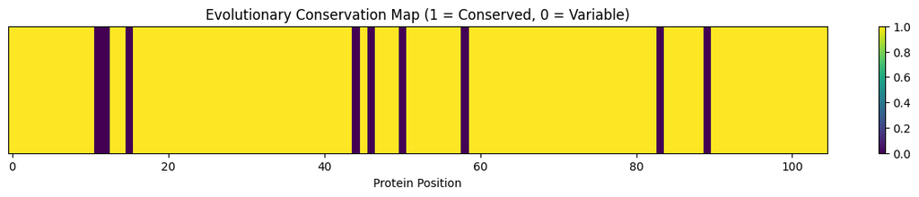

```python
# ============================================================
# EVOLUTIONARY CONSERVATION MAP
# ============================================================

binary_states = [

    1 if state == "C" else 0

    for state in state_sequence

]

plt.figure(figsize=(16, 2))

plt.imshow(

    [binary_states],

    aspect='auto'

)

plt.yticks([])

plt.xlabel("Protein Position")

plt.title(

    "Evolutionary Conservation Map "
    "(1 = Conserved, 0 = Variable)"

)

plt.colorbar()

plt.show()
```

# Interpretation — Evolutionary Conservation Map

The evolutionary conservation map visualizes conserved and variable amino acid positions across the analyzed cytochrome c protein sequences.

### Map Interpretation

- Yellow regions (`1`) represent highly conserved positions.
- Dark regions (`0`) represent variable positions where evolutionary mutations were observed.

### Key Observations

- Most positions across the protein are highly conserved.
- Only a small number of positions show evolutionary variability.
- Variable positions are localized to specific regions rather than being distributed uniformly throughout the sequence.

### Biological Interpretation

The strong dominance of conserved positions suggests that cytochrome c is under significant evolutionary constraint. Since cytochrome c plays an essential role in cellular respiration and electron transport, many amino acid residues are likely functionally or structurally critical and therefore resistant to mutation.

The limited variable positions indicate mutation-tolerant regions where amino acid substitutions can occur without severely disrupting protein function.

### Evolutionary Significance

This conservation pattern supports several important evolutionary principles:

- functionally critical proteins evolve more slowly
- conserved residues are maintained through selective pressure
- mutation-tolerant regions contribute to controlled evolutionary adaptability

### Computational Significance

The conservation map directly supported later stages of the project, including:

- evolutionary state modeling
- mutation hotspot analysis
- conservation-aware mutation simulation
- fitness-based evolutionary selection
- probabilistic ancestral reconstruction

# Final Project Closure and Conclusion

## Project Overview

This project explored the development of a computational evolutionary reconstruction framework focused on ancestral sequence inference, probabilistic reverse translation, evolutionary modeling, and lineage divergence simulation using cytochrome c protein sequences from multiple species.

The study combined concepts from:

- bioinformatics
- evolutionary biology
- probabilistic modeling
- ancestral sequence reconstruction
- computational simulation

to create an integrated evolutionary analysis pipeline.

# Motivation of the Project

The central motivation of this work was to investigate whether evolutionary information preserved in modern protein sequences could be computationally utilized to:

- reconstruct probable ancestral protein sequences
- infer biologically plausible ancestral DNA sequences
- model evolutionary mutation dynamics
- simulate lineage divergence across generations
- evaluate how much ancestral information remains recoverable after evolutionary drift

This idea relates conceptually to reverse-central-dogma-inspired reconstruction approaches, where biological sequence information is computationally traced backward from observed protein sequences toward probable ancestral genomic states.

# Objectives

The major objectives of the project were:

- analyze evolutionary conservation across homologous protein sequences
- reconstruct ancestral protein sequences using probabilistic inference
- generate plausible ancestral DNA sequences through reverse translation
- model evolutionary conservation and variability states
- simulate mutation-driven evolutionary progression
- incorporate selection pressure into evolutionary dynamics
- simulate branching evolutionary lineages
- validate ancestral reconstruction recoverability from evolved descendants

# Dataset and Biological System

The project utilized cytochrome c protein sequences obtained from multiple species including:

- human
- chimpanzee
- gorilla
- mouse
- rat

Cytochrome c was selected because it is a highly conserved protein involved in cellular respiration and electron transport, making it biologically suitable for evolutionary conservation analysis and ancestral reconstruction studies.

# Methodology

## 1. Sequence Collection and Validation

Protein FASTA sequences from multiple species were collected and validated to ensure:

- sequence consistency
- valid amino acid composition
- comparable sequence lengths

## 2. Evolutionary Comparison

Pairwise sequence comparison was performed to identify:

- sequence similarity
- mutation positions
- evolutionary divergence patterns

This revealed strong conservation among primate sequences and measurable divergence between primates and rodents.

## 3. Multiple Sequence Alignment and Conservation Analysis

Protein sequences were aligned to identify:

- conserved residues
- mutation hotspots
- variable evolutionary positions

A conservation map was generated to visualize conserved and mutation-tolerant regions across the protein.

## 4. Phylogenetic Relationship Modeling

Evolutionary distance matrices were constructed and used to generate phylogenetic trees representing evolutionary relationships between species.

This established the evolutionary structure required for ancestral inference.

## 5. Ancestral Sequence Reconstruction

A consensus-based probabilistic reconstruction approach was used to estimate ancestral protein sequences from descendant species sequences.

Position-wise residue probabilities were calculated to estimate ancestral confidence levels.

## 6. Reverse Translation

The reconstructed ancestral protein sequence was reverse translated into a probable ancestral DNA sequence using:

- deterministic codon mapping
- probabilistic codon selection

This introduced biologically plausible codon variability into ancestral DNA reconstruction.

## 7. Evolutionary State Modeling

Protein positions were classified into hidden evolutionary states:

- conserved states
- variable states

Transition probabilities between states were estimated to model evolutionary conservation dynamics in an HMM-inspired framework.

## 8. Evolutionary Simulation

Mutation-driven evolutionary simulations were performed to model sequence evolution across generations.

The simulations incorporated:

- probabilistic mutation events
- conservation-aware mutation rates
- biochemically weighted substitutions

## 9. Selection-Based Evolution

Fitness-aware evolutionary selection was introduced to simulate natural selection pressure.

Sequences with lower fitness scores were progressively removed from the evolutionary process.

## 10. Branching Evolutionary Simulation

Independent evolutionary lineages were simulated to model phylogenetic divergence and evolutionary separation over time.

Lineage divergence matrices quantified evolutionary distance accumulation between descendant branches.

## 11. Ancestral Reconstruction Validation

The evolved descendant lineages were used to reconstruct the ancestral sequence again in order to evaluate ancestral recovery capability.

This tested whether ancestral information remained recoverable after multiple generations of simulated evolution.

# Major Findings

## Strong Evolutionary Conservation

The cytochrome c sequences demonstrated extremely high conservation across species.

Out of 105 amino acid positions:

- 96 positions remained conserved
- only 9 positions showed variability

This indicates strong evolutionary constraint on cytochrome c function.

## Successful Ancestral Reconstruction

The framework successfully reconstructed ancestral protein sequences with high confidence.

The ancestral recovery validation achieved:

- 98 out of 105 positions correctly recovered
- reconstruction accuracy of approximately 93.33%

This demonstrated that substantial ancestral information remained recoverable despite evolutionary divergence.

## Evolutionary Divergence Emergence

Branching simulations demonstrated that independent evolutionary lineages progressively accumulated distinct mutation profiles.

The divergence matrix confirmed substantial lineage separation across independently evolving branches.

## Fitness Degradation Through Mutation Accumulation

Fitness analysis demonstrated that mutation accumulation gradually reduced evolutionary stability across generations.

Selection pressure prevented excessive degradation by filtering low-fitness evolutionary variants.

# Scientific Implications

This project demonstrates how computational approaches can integrate:

- ancestral reconstruction
- probabilistic sequence modeling
- evolutionary simulation
- selection dynamics
- lineage divergence analysis

into a unified evolutionary framework.

The work highlights how modern biological sequence information can preserve recoverable signals of ancestral evolutionary states even after progressive evolutionary divergence.

# Computational Significance

The framework incorporated concepts related to:

- probabilistic modeling
- hidden-state evolutionary systems
- mutation dynamics
- evolutionary fitness landscapes
- phylogenetic divergence modeling

This created a biologically interpretable computational evolutionary reconstruction pipeline.

# Limitations

Although biologically meaningful, the project utilized simplified assumptions including:

- simplified probabilistic codon selection
- limited species dataset
- simplified mutation probability models
- simplified fitness estimation
- consensus-based ancestral inference rather than full likelihood-based phylogenetics

Future work could extend the framework using:

- maximum likelihood ancestral reconstruction
- Bayesian evolutionary inference
- substitution matrices such as PAM or BLOSUM
- structural stability modeling
- large-scale phylogenetic datasets

# Final Conclusion

This project successfully developed a computational evolutionary reconstruction framework capable of integrating ancestral sequence inference, probabilistic reverse translation, evolutionary state modeling, mutation-driven evolutionary simulation, selection-based dynamics, branching lineage divergence, and ancestral recovery validation.

The results demonstrated that highly conserved biological sequences retain significant recoverable ancestral information despite progressive evolutionary divergence and mutation accumulation.

By combining evolutionary biology principles with computational probabilistic modeling and simulation-based analysis, the project established a coherent framework for studying ancestral sequence reconstruction and evolutionary dynamics in a biologically interpretable manner.